# Code to produce figures for manuscript from processed data

```r
out_dir <- "~/HiC/Paper/Figures/"
```

```r
generate.plot.matrix = function(norm.cov, regions, size){

    plot.matrix = matrix(0, ncol=size*3, nrow=length(regions))

      for( i in 1:length(regions)){
            #print(i)
              #get region data
                chr = as.character(seqnames(regions[i]))
                reg.start = start(regions[i])
                reg.end = end(regions[i])
                reg.width = width(regions[i])

                #get coverage of region and flanking areas
                plot.cov = norm.cov[[chr]][(reg.start-reg.width):(reg.end+reg.width)]

                #calculate splines
                plot.matrix[i,] = spline(1:length(plot.cov), plot.cov, n = size*3)$y
          }
      return(plot.matrix)
  }

superpose.eb <-
  function (x, y, ebl, ebu = ebl, length = 0.08, ...){
    arrows(x, y + ebu, x, y - ebl, angle = 90, code = 3, length = length, ...)
  }

ggpie <- function (dat, by, totals) {
    ggplot(dat, aes_string(x=factor(1), y=totals, fill=by)) +
        geom_bar(stat='identity', color='black') +
        coord_polar(theta='y') +
        theme(axis.ticks=element_blank(),
            axis.text=element_blank(),
            axis.title=element_blank(),
            panel.grid=element_blank(),
            panel.border=element_blank(),
            legend.position="none") +
        scale_y_continuous(breaks=cumsum(dat[[totals]]) - dat[[totals]] / 2, labels=dat[[by]]) +
        theme_bw()
}
```

```r
ensGene <- read.table("~/mm9_data/ensGene.txt")
names(ensGene) <- c("bin", "ensGene", "chr", "strand", "txStart", "txEnd",
                    "cdsStart","cdsEnd", "exonCount", "exonStarts", "exonEnds",
                    "score", "name2", "cdsStartStat", "cdsEndStat","exonFrames")
GTP <- read.table("~/mm9_data/ensGtp.txt", sep="\t") #gene/trasncript/protein conversions
names(GTP) <- c("G", "T", "P")

ensGene_tss.gr <- (function(x){
  plus <- x[x$strand=="+",]
  plus$width <- plus$txEnd - plus$txStart
    plus.gr <- GRanges(seqnames=plus$chr,
                       ranges=IRanges(plus$txStart+1, plus$txStart+1),
                       #start coordinates in database are 0-based
                        ensT=plus$ensGene, genelength=plus$width)
    minus <- x[x$strand=="-",]
    minus$width <- minus$txEnd - minus$txStart
    minus.gr <- GRanges(seqnames=minus$chr,
                        ranges=IRanges(minus$txEnd, minus$txEnd),
                        #end coordinates are already 1-based
                        ensT=minus$ensGene, genelength=minus$width)
    tmp <- c(plus.gr,minus.gr)
    tmp <- tmp[seqnames(tmp) %in% paste0("chr", c(1:19, "X", "Y"))]
    })(ensGene)

ensGene_tss.gr$ensG <- GTP$G[match(ensGene_tss.gr$ensT, GTP$T)]


ensGene_bodies.gr <- GRanges(seqnames=ensGene$chr,
                             ranges=IRanges(ensGene$txStart+1, ensGene$txStart+1),
                             #start coordinates in database are 0-based
                                ensT=ensGene$ensGene)
ensGene_bodies.gr$ensG <- GTP$G[match(ensGene_bodies.gr$ensT, GTP$T)]
```

Super-enhancers were defined using [ROSE](https://bitbucket.org/young_computation/rose) (Whyte et al., 2013) with a transcription start site exclusion zone size of 4kb (-t 2000) and the default stitching size of 12.5kb. H3K27ac peaks called by MACS were used as input constituent enhancers, and input-subtracted H3K27ac ChIP-seq signal was used for ranking the stitched regions.

We define a consensus set of super-enhancers by taking the intersection of regions between two biological replicates for each cell type, and then taking the union of these regions between control and cohesin-deficient cells. The remaining regions from ROSE output are then filtered to remove regions within 2.5kb of a transcription start site and a consensus set of conventional enhancers is defined in the same way as for super-enhancers.

```r
data_dir <- "/mnt/biggles/csc_projects/lizis/HiC/VladThymocytes/mm9/ChIPSeq/H3K27ac/Aligned/ROSE_output/"
WT1_enh <- read.table(paste0(data_dir,"DPT_WT1_H3K27ac_mm9_peaks_AllEnhancers.table.txt"),
                      header=T, stringsAsFactors=F)
KO2_enh <- read.table(paste0(data_dir,"DPT_KO2_H3K27ac_mm9_peaks_AllEnhancers.table.txt"),
                      header=T, stringsAsFactors=F)
WT2_enh <- read.table(paste0(data_dir,"DPT_WT2_H3K27ac_mm9_peaks_AllEnhancers.table.txt"),
                      header=T, stringsAsFactors=F)
KO1_enh <- read.table(paste0(data_dir,"DPT_KO1_H3K27ac_mm9_peaks_AllEnhancers.table.txt"),
                      header=T, stringsAsFactors=F)

#transform into GRanges objects

KO1_enh.gr <- makeGRangesFromDataFrame(KO1_enh, keep.extra.columns=TRUE)
KO2_enh.gr <- makeGRangesFromDataFrame(KO2_enh, keep.extra.columns=TRUE)
WT1_enh.gr <- makeGRangesFromDataFrame(WT1_enh, keep.extra.columns=TRUE)
WT2_enh.gr <- makeGRangesFromDataFrame(WT2_enh, keep.extra.columns=TRUE)

gr.list <- list(WT1_enh.gr, WT2_enh.gr, KO1_enh.gr, KO2_enh.gr)
names(gr.list) <- c("WT1", "WT2", "KO1", "KO2")

SE.list <- lapply(gr.list, function(x){
    return(x[x$isSuper==TRUE])
})

nonSE.list <- lapply(gr.list, function(x){
    return(x[x$isSuper==FALSE])
})

#Find enhancers consistent between replicates, give ID based on length ranking
WT_nonSE_both <- BiocGenerics::intersect(nonSE.list$WT1, nonSE.list$WT2)
KO_nonSE_both <- BiocGenerics::intersect(nonSE.list$KO1, nonSE.list$KO2)
join_nonSE <-  BiocGenerics::union(WT_nonSE_both, KO_nonSE_both)

#remove promoters
promoters <- resize(ensGene_tss.gr, fix="center", width=5000)
join_nonSE <- join_nonSE[-queryHits(findOverlaps(join_nonSE, promoters))]

join_nonSE <- join_nonSE[order(-width(join_nonSE))]
join_nonSE$ID <- 1:length(join_nonSE)

## SEs
WT_both <- BiocGenerics::intersect(SE.list$WT1, SE.list$WT2) #n=372
KO_both <- BiocGenerics::intersect(SE.list$KO1, SE.list$KO2) #n=434

join_SEs <-  BiocGenerics::union(WT_both, KO_both)
join_SEs <- join_SEs[order(-width(join_SEs))]
join_SEs$ID <- 1:length(join_SEs)
```

Developmentally regulated enhancers are taken from (Zhang et al., 2012)[http://www.ncbi.nlm.nih.gov/geo/query/acc.cgi?acc=GSE31235]. Peaks for H3K4me2 were called with MACS, for DN3 and DP thymocyte samples. Stable enhancers were defined as those that overlap between DN3 and DP, new enhancers as those which are only present in DP.

```r
data_dir <- "/mnt/biggles/csc_projects/lizis/HiC/VladThymocytes/mm9/Zhang_data/"

DN3_1 <- read.table(paste0(data_dir,"DN3_H3K4me2_Rep1_sorted_peaks.bed"),
                    sep="\t", col.names=c("chr", "start", "end", "id", "score"))
DN3_2 <- read.table(paste0(data_dir,"DN3_H3K4me2_Rep2_sorted_peaks.bed"),
                    sep="\t", col.names=c("chr", "start", "end", "id", "score"))
DP_1 <- read.table(paste0(data_dir,"DP_H3K4me2_Rep1_sorted_peaks.bed"),
                   sep="\t", col.names=c("chr", "start", "end", "id", "score"))
DP_2 <- read.table(paste0(data_dir,"DP_H3K4me2_Rep2_sorted_peaks.bed"),
                   sep="\t", col.names=c("chr", "start", "end", "id", "score"))

DN3_1.gr <- makeGRangesFromDataFrame(DN3_1)
DN3_2.gr <- makeGRangesFromDataFrame(DN3_2)
DP_1.gr <- makeGRangesFromDataFrame(DP_1)
DP_2.gr <- makeGRangesFromDataFrame(DP_2)

DN3.gr <- BiocGenerics::intersect(DN3_1.gr, DN3_2.gr)
DP.gr <- BiocGenerics::intersect(DP_1.gr, DP_2.gr)

DN3.gr <- DN3.gr[width(DN3.gr) >= 100]
DP.gr <- DP.gr[width(DP.gr) >= 100]

fO <- findOverlaps(DN3.gr, DP.gr)

DN3_only.gr <- DN3.gr[-queryHits(fO)]
DP_only.gr <- DP.gr[-subjectHits(fO)]

DP_stable.gr <- DP.gr[unique(subjectHits(fO))]
```

Gene expression analysis was performed by Andre Faure using MMSEQ and DESeq, as described in Seitan et al., 2013.

```r
#load gene expression data
gene_expr.df <- read.table("~/HiC/data/gene_expression_dataset_df.tsv",
                           sep="\t", header=T, stringsAsFactors=F)
gene_expr.df$ensG <- rownames(gene_expr.df)
rownames(gene_expr.df) <- NULL
#modify as Andre did
#Exclude genes with zero mean in both conditions
gene_expr.df<-subset(gene_expr.df, gene_expr.df$baseMeanA!=0 | gene_expr.df$baseMeanB!=0)
#Add pseudocount to avoid +/-infinite log2 fold changes
gene_expr.df$log2FoldChange_pseudo<-log2((gene_expr.df$baseMeanB+1)/(gene_expr.df$baseMeanA+1))
#Calculate mean across conditions
gene_expr.df$baseMean<-apply(cbind(gene_expr.df$baseMeanB, gene_expr.df$baseMeanA), 1, mean)
```

'Nearest neighbor’ genes are defined by assigning enhancers or super-enhancers to the expressed transcript whose TSS is the nearest to the center of the enhancer. ‘Overlapping genes’ are those where any part of the gene body overlaps an enhancer or super-enhancer. Genes with a TSS within 40kb of a super-enhancer are also considered.

```r
#associate promoters and SEs

#to find nearest expressed gene (>0 in at least one condition)
promoters <- ensGene_tss.gr[ensGene_tss.gr$ensG %in% gene_expr.df$ensG]
#nearest genes to super-enhancer centres (as in Young lab papers)
centres <- resize(join_SEs, fix="center", width=1)
nearest_promoters <- promoters[nearest(centres,promoters)]
nearest_genes_to_SEs <- gene_expr.df[match(nearest_promoters$ensG, gene_expr.df$ensG),]
rownames(nearest_genes_to_SEs) <- NULL
nearest_genes_to_SEs <- unique(nearest_genes_to_SEs)

#genes overlapping SEs
bodies <- ensGene_bodies.gr[ensGene_bodies.gr$ensG %in% gene_expr.df$ensG]
fO <- findOverlaps(bodies, join_SEs)
overlap_SE_bodies <- bodies[queryHits(fO)]
overlap_SE_genes <- gene_expr.df[match(overlap_SE_bodies$ensG, gene_expr.df$ensG),]
rownames(overlap_SE_genes) <- NULL
overlap_SE_genes <- unique(overlap_SE_genes)
#remove transcript IDs and collapse
#SE may overlap start of multiple transcripts but expression is at gene level

#genes within 40kb
fO <- findOverlaps(promoters, join_SEs, maxgap=40000)
within40kb_promoters <- promoters[queryHits(fO)]
within40kb_genes <- gene_expr.df[match(within40kb_promoters$ensG, gene_expr.df$ensG),]
rownames(within40kb_genes) <- NULL
within40kb_genes <- unique(within40kb_genes)

#get enhancer centres and nearest promoters
centres <- resize(join_nonSE, fix="center", width=1)

nearest_promoters <- promoters[nearest(centres,promoters)]
nearest_genes_to_nonSEs <- gene_expr.df[match(nearest_promoters$ensG, gene_expr.df$ensG),]
rownames(nearest_genes_to_nonSEs) <- NULL
nearest_genes_to_nonSEs <- unique(nearest_genes_to_nonSEs)
#extra step here - remove any that are also associated with SEs
nearest_genes_to_nonSEs <- nearest_genes_to_nonSEs[!(nearest_genes_to_nonSEs$ensG %in% nearest_genes_to_SEs$ensG),]

#get genes overlapping typical enhancers in the gene body

fO <- findOverlaps(bodies, join_nonSE)
overlap_bodies <- bodies[queryHits(fO)]
overlap_bodies <- gene_expr.df[match(overlap_bodies$ensG, gene_expr.df$ensG),]
rownames(overlap_bodies) <- NULL
overlap_bodies <- unique(overlap_bodies)

## collect into data frame for plotting
all.df <- rbind(cbind(nearest_genes_to_nonSEs, Group="nearest_enh"),
  cbind(overlap_bodies, Group="overlap_enh"),
  cbind(nearest_genes_to_SEs, Group="nearest_SE"),
  cbind(overlap_SE_genes, Group="overlap_SE"),
  cbind(gene_expr.df, Group="expressed_genes"),
  cbind(within40kb_genes, Group="within40kb"))

all.df$Group <- factor(all.df$Group,
                       levels = c("expressed_genes", "nearest_enh", "overlap_enh",
                                  "within40kb", "overlap_SE", "nearest_SE"))
```

### Figure 1A – Regression model

We used a multinomial logistic regression model to predict gene expression changes in cohesin-deficient thymocytes as previously described (Seitan et al., 2013). In addition to the previously used features, we included the variables 'Next to enhancer' (genes that are nearest neighbors of conventional enhancers), 'Near enhancer cluster' (genes positioned within 40kb of an enhancer cluster) and 'Next to enhancer cluster’ (genes that are nearest neighbors of super-enhancers).

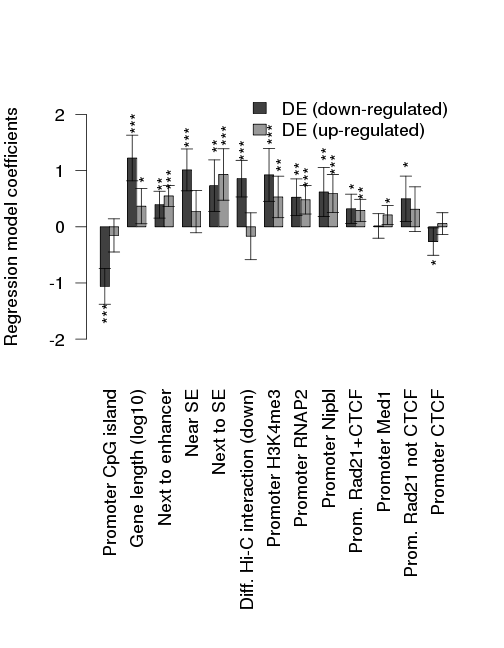

```r
#colours
col_green<-rgb(0, 191, 50, maxColorValue=255)
col_orange<-rgb(255, 191, 0, maxColorValue=255)

col_up <- "grey60"
col_down <- "grey25"

#same data on gene expr as earlier, but slightly different processing
exp_tab <- read.table("~/HiC/data/gene_expression_dataset_df.tsv",
                      sep="\t", header=T, stringsAsFactors=F)
exp_tab$y<-as.factor(exp_tab$DE_up-exp_tab$DE_down)
#Define "0" as reference level
exp_tab$y<-relevel(exp_tab$y, ref="0")
#Scale gene length to [0,1]
temp<-ecdf(exp_tab$log10GeneLength)
exp_tab$log10GeneLength_scale<-temp(exp_tab$log10GeneLength)

#Scale mean expression to [0,1]
temp<-ecdf(exp_tab$baseMeanA + exp_tab$baseMeanB)
exp_tab$meanExpr_scale <- temp(exp_tab$baseMeanA + exp_tab$baseMeanB)


#add more factor columns
exp_tab$nearest_enh <- 0
exp_tab$nearest_enh[rownames(exp_tab) %in% nearest_genes_to_nonSEs$ensG] <- 1
exp_tab$overlap_enh <- 0
exp_tab$overlap_enh[rownames(exp_tab) %in% overlap_bodies$ensG] <- 1
exp_tab$SE_within_40kb <- 0
exp_tab$SE_within_40kb[rownames(exp_tab) %in% within40kb_genes$ensG] <- 1
exp_tab$nearest_SE <- 0
exp_tab$nearest_SE[rownames(exp_tab) %in% nearest_genes_to_SEs$ensG] <- 1
exp_tab$overlap_SE <- 0
exp_tab$overlap_SE[rownames(exp_tab) %in% overlap_SE_genes$ensG] <- 1

#run model
#Build multivariate model (CNC, RAD21+CTCF)
exp_mlrm<-multinom(y ~ prom_CNC+DI_down+DI_up+DI_rand+prom_CTCF+prom_Med1+prom_Nipbl+prom_Rad21_CTCF+prom_H3K4me3+prom_RNAP2+log10GeneLength_scale+CpG_island+RNAP2_pausingindex+nearest_enh+overlap_enh+SE_within_40kb+nearest_SE+overlap_SE, data=exp_tab)
#Get coefficients and coefficient significance
exp_mlrm_summary<-summary(exp_mlrm)
exp_mlrm_coef<-exp_mlrm_summary$coefficients[,2:dim(exp_mlrm_summary$coefficients)[2]]
exp_mlrm_se<-exp_mlrm_summary$standard.errors[,2:dim(exp_mlrm_summary$standard.errors)[2]]
exp_mlrm_sig<-exp_mlrm_se
for(i in 1:dim(exp_mlrm_sig)[2]){
  exp_mlrm_sig[1,i]<-min(pnorm(0, exp_mlrm_coef[1,i], exp_mlrm_se[1,i],
                               lower.tail=T), pnorm(0, exp_mlrm_coef[1,i],
                                                    exp_mlrm_se[1,i], lower.tail=F))*2
  exp_mlrm_sig[2,i]<-min(pnorm(0, exp_mlrm_coef[2,i], exp_mlrm_se[2,i],
                               lower.tail=T), pnorm(0, exp_mlrm_coef[2,i],
                                                    exp_mlrm_se[2,i], lower.tail=F))*2
}

colnames(exp_mlrm_coef) <- c("Prom. Rad21 not CTCF", "Diff. Hi-C interaction (down)",
                             "DI_up","DI_rand", "Promoter CTCF",
                             "Promoter Med1","Promoter Nipbl","Prom. Rad21+CTCF",
                             "Promoter H3K4me3", "Promoter RNAP2",
                             "Gene length (log10)", "Promoter CpG island",
                             "RNAP2_pausing_index", "Next to enhancer",
                             "overlap_enh", "Near SE", "Next to SE", "overlap_SE")
colnames(exp_mlrm_se) <- colnames(exp_mlrm_coef)
colnames(exp_mlrm_sig) <- colnames(exp_mlrm_coef)

exp_mlrm_coef <- exp_mlrm_coef[, c("Promoter CpG island","Gene length (log10)",
                                   "Next to enhancer","Near SE", "Next to SE",
                                   "Diff. Hi-C interaction (down)", "Promoter H3K4me3",
                                   "Promoter RNAP2","Promoter Nipbl",
                                   "Prom. Rad21+CTCF","Promoter Med1",
                                   "Prom. Rad21 not CTCF", "Promoter CTCF")]
exp_mlrm_se <- exp_mlrm_se[,colnames(exp_mlrm_coef)]
exp_mlrm_sig <- exp_mlrm_sig[,colnames(exp_mlrm_coef)]

#plot
par(mar=c(13, 4, 4, 2), cex=1.5)
b<-barplot(exp_mlrm_coef, las=2,
           ylab='Regression model coefficients', beside=T,
           col=c(col_down, col_up), ylim=c(-2.5, 2.5))

superpose.eb(b, exp_mlrm_coef, 1.96*exp_mlrm_se, lwd=1)

text(b, exp_mlrm_coef + ifelse(exp_mlrm_coef > 0, 1, -1)*exp_mlrm_se*3,
     labels=c('', '*')[(exp_mlrm_sig<0.05 & exp_mlrm_sig>=0.01)+1], srt=90)

text(b, exp_mlrm_coef + ifelse(exp_mlrm_coef > 0, 1, -1)*exp_mlrm_se*3,
     labels=c('', '**')[(exp_mlrm_sig<0.01 & exp_mlrm_sig>=0.001)+1], srt=90)

text(b, exp_mlrm_coef + ifelse(exp_mlrm_coef > 0, 1, -1)*exp_mlrm_se*3,
     labels=c('', '***')[(exp_mlrm_sig<0.001)+1], srt=90)

legend("topright", legend=c('DE (down-regulated)', 'DE (up-regulated)'),
       fill=c(col_down, col_up), bty="n")
```

### Figure1B – Do enhancers explain DE genes?

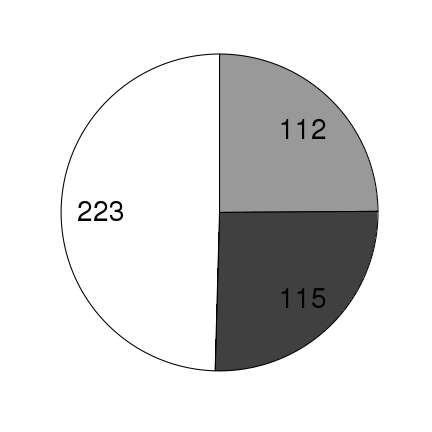

```r
all.df$DE <- "No"
all.df$DE[all.df$DE_up == TRUE] <- "Up"
all.df$DE[all.df$DE_down == TRUE] <- "Down"
all.df$DE <- factor(all.df$DE, levels = c("Down", "Up","No"))

enh_assoc_df <- all.df

## down reg genes
enh_assoc_df %>% filter(DE=="Down") %>%
    filter(Group %in% c("within40kb", "overlap_SE", "nearest_SE")) %>%
    dplyr::select(ensG) %>% unique() %>% unlist() -> down_SE_genes
enh_assoc_df %>% filter(DE=="Down") %>%
    filter(Group %in% c("nearest_enh","overlap_enh")) %>%
    dplyr::select(ensG) %>% unique() %>% unlist() -> down_Enhancer_genes
enh_assoc_df %>% filter(DE=="Down") %>%
    filter(Group=="expressed_genes") %>%
    dplyr::select(ensG) %>% unique() %>% unlist() -> down_All_genes

down_Enhancer_genes <- down_Enhancer_genes[!(down_Enhancer_genes %in% down_SE_genes)]
down_All_genes <- down_All_genes[!((down_All_genes %in% down_SE_genes) | (down_All_genes %in% down_Enhancer_genes))]

down_pie <- c(Enhancer=length(down_Enhancer_genes), SE=length(down_SE_genes), Other=length(down_All_genes))

dat <- data.frame(num=down_pie, category=names(down_pie), labels=down_pie)
dat$ymax = cumsum(dat$num)
dat$ymin = c(0, head(dat$ymax, n=-1))
dat$label <- dat$num

ggplot(dat, aes(fill=category, ymax=ymax, ymin=ymin, xmax=4, xmin=0, label=label)) +
    geom_rect(colour="black") +
    geom_text(aes(x=3, y=(ymax+ymin)/2), size=10) +
    coord_polar(theta="y") +
    xlim(c(0, 4))+
    theme_bw() +
    scale_fill_manual(values=c(Enhancer=col_up, SE=col_down, Other="white")) +
    theme(panel.grid=element_blank()) +
    theme(axis.text=element_blank()) +
    theme(axis.ticks=element_blank()) +
    theme(axis.title=element_blank()) +
    theme(panel.border=element_blank()) +
    theme(legend.position="none")
```

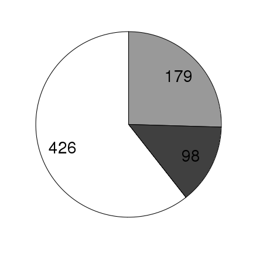

```r
## up reg genes
enh_assoc_df %>% filter(DE=="Up") %>%
    filter(Group %in% c("within40kb", "overlap_SE", "nearest_SE")) %>%
    dplyr::select(ensG) %>% unique() %>% unlist() -> Up_SE_genes
enh_assoc_df %>% filter(DE=="Up") %>%
    filter(Group %in% c("nearest_enh","overlap_enh")) %>%
    dplyr::select(ensG) %>% unique() %>% unlist() -> Up_Enhancer_genes
enh_assoc_df %>% filter(DE=="Up") %>%
    filter(Group=="expressed_genes") %>% dplyr::select(ensG) %>% unique() %>% unlist() -> Up_All_genes

Up_Enhancer_genes <- Up_Enhancer_genes[!(Up_Enhancer_genes %in% Up_SE_genes)]
Up_All_genes <- Up_All_genes[!((Up_All_genes %in% Up_SE_genes) | (Up_All_genes %in% Up_Enhancer_genes))]

Up_pie <- c(Enhancer=length(Up_Enhancer_genes), SE=length(Up_SE_genes), Other=length(Up_All_genes))

dat <- data.frame(num=Up_pie, category=names(Up_pie), labels=Up_pie)
dat$ymax = cumsum(dat$num)
dat$ymin = c(0, head(dat$ymax, n=-1))
dat$label <- dat$num

ggplot(dat, aes(fill=category, ymax=ymax, ymin=ymin, xmax=4, xmin=0, label=label)) +
    geom_rect(colour="black") +
    geom_text(aes(x=3, y=(ymax+ymin)/2), size=10) +
    coord_polar(theta="y") +
    xlim(c(0, 4))+
    theme_bw() +
    scale_fill_manual(values=c(Enhancer=col_up, SE=col_down, Other="white")) +
    theme(panel.grid=element_blank()) +
    theme(axis.text=element_blank()) +
    theme(axis.ticks=element_blank()) +
    theme(axis.title=element_blank()) +
    theme(panel.border=element_blank()) +
    theme(legend.position="none")
```

## Figure 1C: Genes near enhancers are more likely to be deregulated

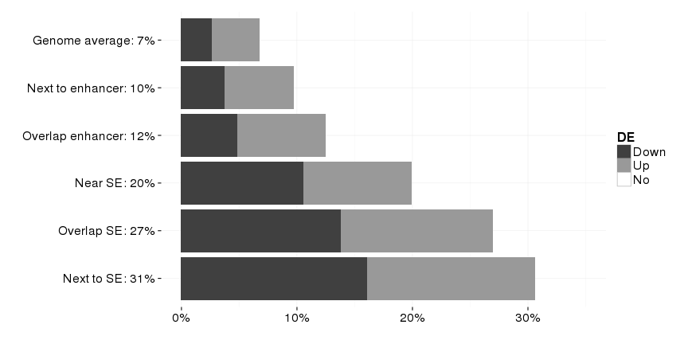

```r
##Plot % genes nonDE, Up, or Down
all.df %>%
  dplyr::select(ensG, DE_up, DE_down, DE, Group) %>%
  group_by(Group, DE) %>%
  summarise(count=n()) %>%
  ungroup() %>% ##dplyr bug :(
  spread(DE, count) -> DE_mat

DE_mat <- mutate(DE_mat, Percentage=round(100*(Up+Down)/(Up+Down+No)))

cols <- c("No" = NA, "Up" = col_up, "Down" = col_down)
labs <- c("Genome average", "Next to enhancer", "Overlap enhancer", "Near SE", "Overlap SE", "Next to SE")
labs<- rev(paste0(labs, ": ", DE_mat$Percentage, "%"))

ggplot(all.df, aes(x=Group, fill=DE)) + geom_bar(position="fill") +
  scale_y_continuous("",labels=percent,limits=c(0,0.35)) +
  scale_x_discrete("", labels=labs, limits=c("nearest_SE", "overlap_SE",
                                             "within40kb", "overlap_enh", "nearest_enh", "expressed_genes")) +
  scale_fill_manual(values=cols) +
  theme_bw(base_size=20) + theme(panel.border=element_blank()) + coord_flip()
```

Data for the graph above and chi-squared tests comparing each category to the genome-wide average.

```r
kable(DE_mat)
```

| Group | Down | Up | No | Percentage |
| --- | --- | --- | --- | --- |
| expressed_genes | 450 | 703 | 15850 | 7 |
| nearest_enh | 115 | 185 | 2780 | 10 |
| overlap_enh | 7 | 11 | 126 | 12 |
| within40kb | 110 | 97 | 829 | 20 |
| overlap_SE | 61 | 58 | 322 | 27 |
| nearest_SE | 72 | 65 | 310 | 31 |

```r
DE_mat %>%
  dplyr::select(No,Up,Down) %>%
  as.matrix() %>%
  chisq.test()
```

```
##
##  Pearson's Chi-squared test
##
## data:  DE_mat %>% dplyr::select(No, Up, Down) %>% as.matrix()
## X-squared = 769.1191, df = 10, p-value < 2.2e-16
```

```r
groups <- unique(DE_mat$Group[DE_mat$Group!="expressed_genes"])
for (g in groups){
  print(paste0("Comparing all expressed genes and ", g, ":"))

  DE_mat %>%
    filter(Group %in% c("expressed_genes", g)) %>%
    dplyr::select(No,Up,Down) %>%
    (function(x){x[1,] <- x[1,]-x[2,]
                 return(x)}) %>%  print()

  DE_mat %>%
    filter(Group %in% c("expressed_genes", g)) %>%
    dplyr::select(No,Up,Down) %>%
    (function(x){x[1,] <- x[1,]-x[2,]
                 return(x)}) %>%
    as.matrix() %>%
    chisq.test() %>% print()
  }
```

```
## [1] "Comparing all expressed genes and nearest_enh:"
## Source: local data frame [2 x 3]
##
##      No  Up Down
## 1 13070 518  335
## 2  2780 185  115
##
##  Pearson's Chi-squared test
##
## data:  DE_mat %>% filter(Group %in% c("expressed_genes", g)) %>% dplyr::select(No,     Up, Down) %>% (function(x) {    x[1, ] <- x[1, ] - x[2, ]    return(x)}) %>% as.matrix()
## X-squared = 52.2091, df = 2, p-value = 4.602e-12
##
## [1] "Comparing all expressed genes and overlap_enh:"
## Source: local data frame [2 x 3]
##
##      No  Up Down
## 1 15724 692  443
## 2   126  11    7
##
##  Pearson's Chi-squared test
##
## data:  DE_mat %>% filter(Group %in% c("expressed_genes", g)) %>% dplyr::select(No,     Up, Down) %>% (function(x) {    x[1, ] <- x[1, ] - x[2, ]    return(x)}) %>% as.matrix()
## X-squared = 7.5142, df = 2, p-value = 0.02335
##
## [1] "Comparing all expressed genes and within40kb:"
## Source: local data frame [2 x 3]
##
##      No  Up Down
## 1 15021 606  340
## 2   829  97  110
##
##  Pearson's Chi-squared test
##
## data:  DE_mat %>% filter(Group %in% c("expressed_genes", g)) %>% dplyr::select(No,     Up, Down) %>% (function(x) {    x[1, ] <- x[1, ] - x[2, ]    return(x)}) %>% as.matrix()
## X-squared = 358.4209, df = 2, p-value < 2.2e-16
##
## [1] "Comparing all expressed genes and overlap_SE:"
## Source: local data frame [2 x 3]
##
##      No  Up Down
## 1 15528 645  389
## 2   322  58   61
##
##  Pearson's Chi-squared test
##
## data:  DE_mat %>% filter(Group %in% c("expressed_genes", g)) %>% dplyr::select(No,     Up, Down) %>% (function(x) {    x[1, ] <- x[1, ] - x[2, ]    return(x)}) %>% as.matrix()
## X-squared = 322.8969, df = 2, p-value < 2.2e-16
##
## [1] "Comparing all expressed genes and nearest_SE:"
## Source: local data frame [2 x 3]
##
##      No  Up Down
## 1 15540 638  378
## 2   310  65   72
##
##  Pearson's Chi-squared test
##
## data:  DE_mat %>% filter(Group %in% c("expressed_genes", g)) %>% dplyr::select(No,     Up, Down) %>% (function(x) {    x[1, ] <- x[1, ] - x[2, ]    return(x)}) %>% as.matrix()
## X-squared = 462.5945, df = 2, p-value < 2.2e-16
```

### Figure 2C – H3K27ac correlates between WT and KO

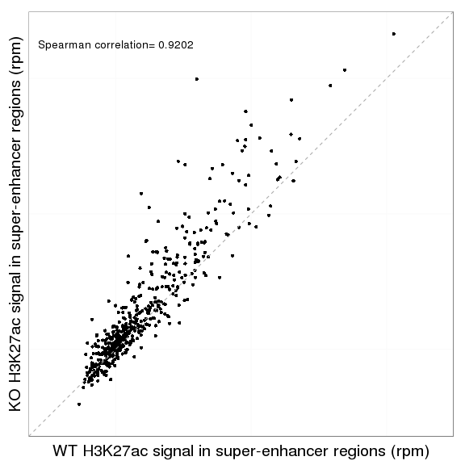

```r
load("~/HiC/data/H3K27ac_norm_coverage_list.RData")

## Super-enhancers
#create matrices of signal in 1000 bins
windows <- join_SEs <- join_SEs[rev(order(width(join_SEs)))]
targets <- H3K27ac_coverage_list

join_smList<- ScoreMatrixList(windows=windows, targets=targets, bin.num=1000)

WT1_totals <- apply(join_smList$WT1_H3K27ac,1,sum)
WT2_totals <- apply(join_smList$WT2_H3K27ac,1,sum)
KO1_totals <- apply(join_smList$KO1_H3K27ac, 1, sum)
KO2_totals <- apply(join_smList$KO2_H3K27ac, 1, sum)
totals.df <- data.frame(ID =1:length(WT1_totals), WT1_totals,WT2_totals, KO1_totals,KO2_totals)
totals.df$WT_mean <- (totals.df$WT1_totals + totals.df$WT2_totals)/2
totals.df$KO_mean <- (totals.df$KO1_totals + totals.df$KO2_totals)/2
totals.df$ratio <- totals.df$KO_mean / totals.df$WT_mean

WTKOcor <- signif(cor(totals.df$WT_mean, totals.df$KO_mean, method="spearman"),4)
WTKOratio <- totals.df$ratio

## PLOT FIGURE 2C
ggplot(totals.df, aes(x=WT_mean, y=KO_mean)) +
    theme_bw(base_size=20) + theme(panel.grid.major=element_blank(),
                                   axis.ticks=element_blank(), axis.text=element_blank()) +
    geom_point() +
  labs(x="WT H3K27ac signal in super-enhancer regions (rpm)",
       y="KO H3K27ac signal in super-enhancer regions (rpm)") +
  xlim(0,5700) + ylim(0,5700) + geom_abline(intercept=0, slope=1,
                                            linetype="dashed", colour="darkgrey") +
  annotate("text", x=1000, y=5500, label=paste("Spearman correlation=", WTKOcor))
```

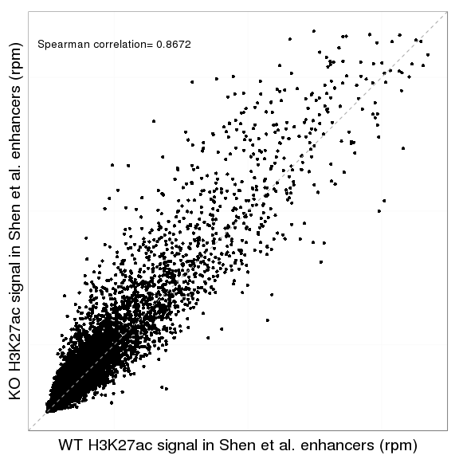

```r
## Shen enhancers
Shen_enhancers <- read.table("~/HiC/data/thymus.enhancers.1kb.bed")
Shen_enhancers.gr <- GRanges(seqnames=Shen_enhancers$V1,
                             ranges=IRanges(Shen_enhancers$V2, Shen_enhancers$V3))

windows2 <- Shen_enhancers.gr

Shen_smlist <- ScoreMatrixList(windows=windows2, targets=targets, bin.num=1000)

WT1_totals <- apply(Shen_smlist$WT1_H3K27ac,1,sum)
WT2_totals <- apply(Shen_smlist$WT2_H3K27ac,1,sum)
KO1_totals <- apply(Shen_smlist$KO1_H3K27ac, 1, sum)
KO2_totals <- apply(Shen_smlist$KO2_H3K27ac, 1, sum)
totals.df <- data.frame(ID =1:length(WT1_totals), WT1_totals,WT2_totals, KO1_totals,KO2_totals)
totals.df$WT_mean <- (totals.df$WT1_totals + totals.df$WT2_totals)/2
totals.df$KO_mean <- (totals.df$KO1_totals + totals.df$KO2_totals)/2
totals.df$ratio <- totals.df$KO_mean / totals.df$WT_mean

Shen_WTKOcor <- signif(cor(totals.df$WT_mean, totals.df$KO_mean, method="spearman"),4)

## PLOT FIGURE 2C
ggplot(totals.df, aes(x=WT_mean, y=KO_mean)) +
 theme_bw(base_size=20) + theme(panel.grid.major=element_blank(),
                                axis.ticks=element_blank(), axis.text=element_blank()) +
    geom_point() +
  labs(x="WT H3K27ac signal in Shen et al. enhancers (rpm)",
       y="KO H3K27ac signal in Shen et al. enhancers (rpm)") +
  xlim(0,5700) + ylim(0,5700) + geom_abline(intercept=0, slope=1,
                                            linetype="dashed", colour="darkgrey") +
  annotate("text", x=1000, y=5500, label=paste("Spearman correlation=", Shen_WTKOcor))
```

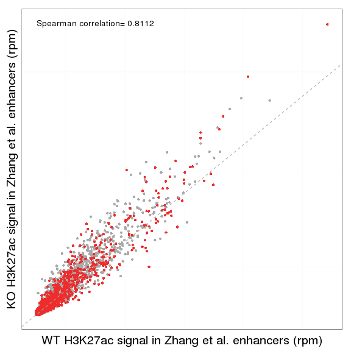

```r
## Zhang enhancers
windows <- DP_stable.gr
targets <- H3K27ac_coverage_list

stable_smlist <- ScoreMatrixList(windows=windows, targets=targets, bin.num=100)

WT1_totals <- apply(stable_smlist$WT1_H3K27ac,1,sum)
WT2_totals <- apply(stable_smlist$WT2_H3K27ac,1,sum)
KO1_totals <- apply(stable_smlist$KO1_H3K27ac, 1, sum)
KO2_totals <- apply(stable_smlist$KO2_H3K27ac, 1, sum)
stable.df <- data.frame(ID =1:length(WT1_totals), WT1_totals,WT2_totals, KO1_totals,KO2_totals)
stable.df$WT_mean <- (stable.df$WT1_totals + stable.df$WT2_totals)/2
stable.df$KO_mean <- (stable.df$KO1_totals + stable.df$KO2_totals)/2
stable.df$ratio <- stable.df$KO_mean / stable.df$WT_mean
stable.df$group <- "Stable"

windows <- DP_only.gr
targets <- H3K27ac_coverage_list

new_smlist <- ScoreMatrixList(windows=windows, targets=targets, bin.num=100)

WT1_totals <- apply(new_smlist$WT1_H3K27ac,1,sum)
WT2_totals <- apply(new_smlist$WT2_H3K27ac,1,sum)
KO1_totals <- apply(new_smlist$KO1_H3K27ac, 1, sum)
KO2_totals <- apply(new_smlist$KO2_H3K27ac, 1, sum)
new.df <- data.frame(ID =1:length(WT1_totals), WT1_totals,WT2_totals, KO1_totals,KO2_totals)
new.df$WT_mean <- (new.df$WT1_totals + new.df$WT2_totals)/2
new.df$KO_mean <- (new.df$KO1_totals + new.df$KO2_totals)/2
new.df$ratio <- new.df$KO_mean / new.df$WT_mean
new.df$group <- "New"

totals.df <- rbind(stable.df, new.df)

WTKOcor <- signif(cor(totals.df$WT_mean, totals.df$KO_mean, method="spearman"),4)

## PLOT FIGURE 2C
ggplot(totals.df, aes(x=WT_mean, y=KO_mean, colour=group)) +
    theme_bw(base_size=20) +
    theme(panel.grid.major=element_blank(), axis.ticks=element_blank(),
          axis.text=element_blank(), legend.position="none") +
  geom_point(size=2) +
  scale_colour_manual(values=c("firebrick2","darkgrey")) +
  labs(x="WT H3K27ac signal in Zhang et al. enhancers (rpm)",
       y="KO H3K27ac signal in Zhang et al. enhancers (rpm)") +
  geom_abline(intercept=0, slope=1, linetype="dashed", colour="darkgrey") +
  annotate("text", x=250, y=1500, label=paste("Spearman correlation=", WTKOcor))
```

### Figure 2D – H3K27ac changes don't explain deregulation

```r
#get gene-SE pairs
#genes within 40kb
fO <- findOverlaps(promoters, join_SEs, maxgap=40000)
within40kb_promoters <- promoters[queryHits(fO)]
within40kb_genes <- gene_expr.df[match(within40kb_promoters$ensG, gene_expr.df$ensG),]
within40kb_genes$ID <- subjectHits(fO)
rownames(within40kb_genes) <- NULL
within40kb_genes <- unique(within40kb_genes)

# note that some genes are repeated
#1097 rows, 1036 unique genes

#get SEs with H3K27ac data
windows <- join_SEs <- join_SEs[rev(order(width(join_SEs)))]
targets <- H3K27ac_coverage_list

join_smList<- ScoreMatrixList(windows=windows, targets=targets, bin.num=1000)

WT1_totals <- apply(join_smList$WT1_H3K27ac,1,sum)
WT2_totals <- apply(join_smList$WT2_H3K27ac,1,sum)
KO1_totals <- apply(join_smList$KO1_H3K27ac, 1, sum)
KO2_totals <- apply(join_smList$KO2_H3K27ac, 1, sum)
SE_totals.df <- data.frame(ID =1:length(WT1_totals), WT1_totals,WT2_totals, KO1_totals,KO2_totals)
SE_totals.df$WT_mean <- (SE_totals.df$WT1_totals + SE_totals.df$WT2_totals)/2
SE_totals.df$KO_mean <- (SE_totals.df$KO1_totals + SE_totals.df$KO2_totals)/2
SE_totals.df$log2ratio <- log2(SE_totals.df$KO_mean / SE_totals.df$WT_mean)

#combine
genes_SEs_H3K27ac <- merge(within40kb_genes, SE_totals.df,
                           by="ID")[, c("ID", "log2ratio", "WT_mean", "KO_mean",
                                        "ensG", "DE_down", "DE_up", "log2FoldChange_pseudo",
                                        "prom_CTCF", "prom_Rad21", "prom_Rad21_CTCF")]

genes_SEs_H3K27ac$promoter_mark <- "None"
genes_SEs_H3K27ac$promoter_mark[genes_SEs_H3K27ac$prom_CTCF==TRUE] <- "CTCF"
genes_SEs_H3K27ac$promoter_mark[genes_SEs_H3K27ac$prom_Rad21==TRUE] <- "Rad21"
genes_SEs_H3K27ac$promoter_mark[genes_SEs_H3K27ac$prom_Rad21_CTCF==TRUE] <- "Both"

genes_SEs_H3K27ac$DE <- "No"
genes_SEs_H3K27ac$DE[genes_SEs_H3K27ac$DE_up == TRUE] <- "Up"
genes_SEs_H3K27ac$DE[genes_SEs_H3K27ac$DE_down == TRUE] <- "Down"
genes_SEs_H3K27ac$DE <- factor(genes_SEs_H3K27ac$DE, levels = c("No", "Down", "Up"))

cols <- c("No" = "grey50", "Up" = muted("red"), "Down" = muted("blue"))
```

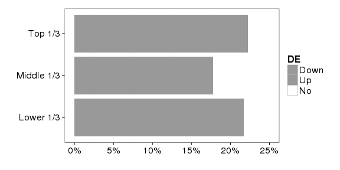

```r
#get cutoffs:
genes_SEs_H3K27ac$H3K27ac_group <- factor(cut(genes_SEs_H3K27ac$log2ratio,
                                              quantile(genes_SEs_H3K27ac$log2ratio,
                                                       probs = seq(0,1, length.out=4)), include.lowest = TRUE),
                                          labels = c("Lower 1/3", "Middle 1/3", "Top 1/3"))
genes_SEs_H3K27ac$DE <- factor(genes_SEs_H3K27ac$DE, c("Down","Up", "No"))

cols <- c("No" = NA, "Up" = col_up, "Down" = col_up)
#plot
ggplot(genes_SEs_H3K27ac, aes(x=H3K27ac_group, fill=DE)) + geom_bar(position="fill") +
  scale_y_continuous("",labels=percent, limits=c(0,0.25)) +
  scale_x_discrete("") +
  scale_fill_manual(values=cols) +
  theme_bw(base_size=20) + theme(panel.grid.major=element_blank())  + coord_flip()
```

```r
genes_SEs_H3K27ac %>%
  dplyr::select(ensG, DE_up, DE_down, DE, H3K27ac_group) %>%
  group_by(H3K27ac_group, DE) %>%
  summarise(count=n()) %>%
  ungroup() %>% ##dplyr bug :(
  spread(DE, count) %>% kable()
```

| H3K27ac_group | Down | Up | No |
| --- | --- | --- | --- |
| Lower 1/3 | 72 | 8 | 288 |
| Middle 1/3 | 35 | 30 | 300 |
| Top 1/3 | 17 | 64 | 283 |

```r
#get enhancer centres and nearest promoters
centres <- resize(join_nonSE, fix="center", width=1)

nearest_promoters <- promoters[nearest(centres,promoters)]
nearest_genes_to_nonSEs <- gene_expr.df[match(nearest_promoters$ensG, gene_expr.df$ensG),]

nearest_genes_to_nonSEs$ID <- centres$ID
rownames(nearest_genes_to_nonSEs) <- NULL
nearest_genes_to_nonSEs <- unique(nearest_genes_to_nonSEs)

#extra step here - remove any that are also associated with SEs
nearest_genes_to_nonSEs <- nearest_genes_to_nonSEs[!(nearest_genes_to_nonSEs$ensG %in% nearest_genes_to_SEs$ensG),]

# note that some genes are repeated
#5048 rows, 3540 unique genes

#get SEs with H3K27ac data
windows <- join_nonSE <- join_nonSE[rev(order(width(join_nonSE)))]
targets <- H3K27ac_coverage_list

join_smList<- ScoreMatrixList(windows=windows, targets=targets, bin.num=1000)

WT1_totals <- apply(join_smList$WT1_H3K27ac,1,sum)
WT2_totals <- apply(join_smList$WT2_H3K27ac,1,sum)
KO1_totals <- apply(join_smList$KO1_H3K27ac, 1, sum)
KO2_totals <- apply(join_smList$KO2_H3K27ac, 1, sum)
totals.df <- data.frame(ID =1:length(WT1_totals), WT1_totals,WT2_totals, KO1_totals,KO2_totals)
totals.df$WT_mean <- (totals.df$WT1_totals + totals.df$WT2_totals)/2
totals.df$KO_mean <- (totals.df$KO1_totals + totals.df$KO2_totals)/2
totals.df$log2ratio <- log2(totals.df$KO_mean / totals.df$WT_mean)

#combine
genes_enh_H3K27ac <- merge(nearest_genes_to_nonSEs, totals.df,
                           by="ID")[, c("ID", "log2ratio", "ensG", "DE_down", "DE_up", "log2FoldChange_pseudo")]

genes_enh_H3K27ac$DE <- "No"
genes_enh_H3K27ac$DE[genes_enh_H3K27ac$DE_up == TRUE] <- "Up"
genes_enh_H3K27ac$DE[genes_enh_H3K27ac$DE_down == TRUE] <- "Down"
genes_enh_H3K27ac$DE <- factor(genes_enh_H3K27ac$DE, levels = c("No", "Down", "Up"))

cols <- c("No" = "grey50", "Up" = muted("red"), "Down" = muted("blue"))
```

```r
#get cutoffs:
genes_enh_H3K27ac$H3K27ac_group <- factor(cut(genes_enh_H3K27ac$log2ratio,
                                              quantile(genes_enh_H3K27ac$log2ratio,
                                                       probs = seq(0,1, length.out=4)), include.lowest = TRUE),
                                          labels = c("Lower 1/3", "Middle 1/3", "Top 1/3"))
genes_enh_H3K27ac$DE <- factor(genes_enh_H3K27ac$DE, c("Down","Up", "No"))
table(genes_enh_H3K27ac$H3K27ac_group)
```

```
##
##  Lower 1/3 Middle 1/3    Top 1/3
##       1322       1322       1322
```

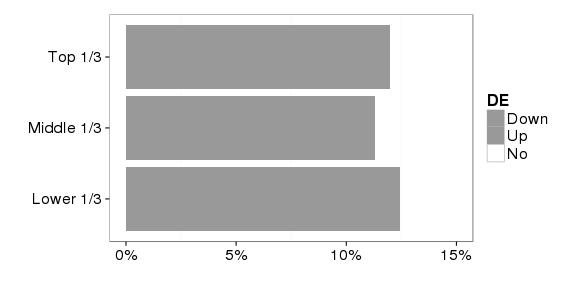

```r
#plot
cols <- c("No" = NA, "Up" = col_up, "Down" = col_up)
#plot
ggplot(genes_enh_H3K27ac, aes(x=H3K27ac_group, fill=DE)) + geom_bar(position="fill") +
  scale_y_continuous("",labels=percent, limits=c(0,0.15)) +
  scale_x_discrete("") +
  scale_fill_manual(values=cols) +
  theme_bw(base_size=20) + theme(panel.grid.major=element_blank())  + coord_flip()
```

```r
genes_enh_H3K27ac %>%
  dplyr::select(ensG, DE_up, DE_down, DE, H3K27ac_group) %>%
  group_by(H3K27ac_group, DE) %>%
  summarise(count=n()) %>%
  ungroup() %>% ##dplyr bug :(
  spread(DE, count) %>% kable()
```

| H3K27ac_group | Down | Up | No |
| --- | --- | --- | --- |
| Lower 1/3 | 95 | 70 | 1157 |
| Middle 1/3 | 56 | 94 | 1172 |
| Top 1/3 | 41 | 118 | 1163 |

### Figure 3A and B – cohesin and CTCF signal at enhancers and super-enhancers

```r
load("/mnt/biggles/csc_projects/lizis/ES-DPT/DPT/DPT_normalised_coverage_list.RData")
load("~/HiC/data/DKO_H3K27ac_normalised_coverage.RData")

normalised_coverage_list_all <- list(Rad21=normalised_coverage_list$Rad21,
                                       CTCF=normalised_coverage_list$CTCF_Shih,
                                       Smc1a=normalised_coverage_list$Smc1a,
                                       WT1_H3K27ac = H3K27ac_coverage_list$WT1_H3K27ac,
                                       WT2_H3K27ac = H3K27ac_coverage_list$WT2_H3K27ac,
                                       KO1_H3K27ac = H3K27ac_coverage_list$KO1_H3K27ac,
                                       KO2_H3K27ac = H3K27ac_coverage_list$KO2_H3K27ac,
                                       Nipbl = normalised_coverage_list$Nipbl,
                                       Med1 = normalised_coverage_list$Med1,
                                       H3K4me3 = normalised_coverage_list$H3K4me3,
                                       H3K4me1 = normalised_coverage_list$H3K4me1)

size=100
SE.plot.matrix.list <- lapply(normalised_coverage_list_all,
                              function(x){generate.plot.matrix(x, join_SEs, size)})
names(SE.plot.matrix.list) <- names(normalised_coverage_list_all)

nonSE.plot.matrix.list <- lapply(normalised_coverage_list_all,
                                 function(x){generate.plot.matrix(x, join_nonSE, size)})
names(nonSE.plot.matrix.list) <- names(normalised_coverage_list_all)
```

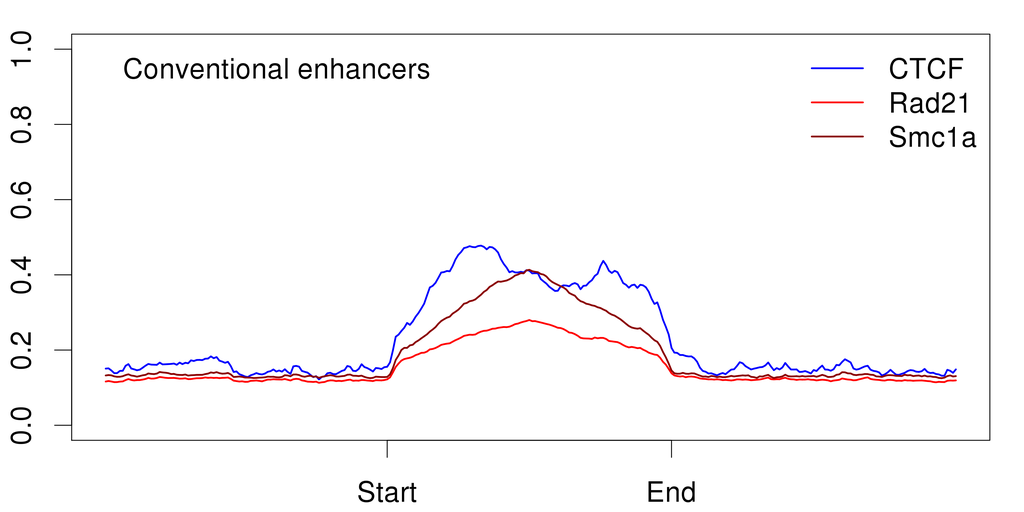

```r
## PLOT FIGURE 3A
par(cex=2, mar=c(2.1,2.1,1,1))
plot(colMeans(nonSE.plot.matrix.list$CTCF), type="l", ylab= "ChIP-seq signal",
     ylim =c(0,1), xaxt="n", xlab="", col="blue", lwd=2, ann=FALSE)
axis(side=1, at=c(size,size*2), labels=c("Start", "End"))

lines(colMeans(nonSE.plot.matrix.list$Rad21), col="red", lwd=2)
lines(colMeans(nonSE.plot.matrix.list$Smc1a), col="darkred", lwd=2)

legend("topright", legend = c("CTCF", "Rad21", "Smc1a"),
       col = c("blue", "red", "darkred"), lty=1, lwd=2, bty="n")
legend("topleft", legend="Conventional enhancers", bty="n")
```

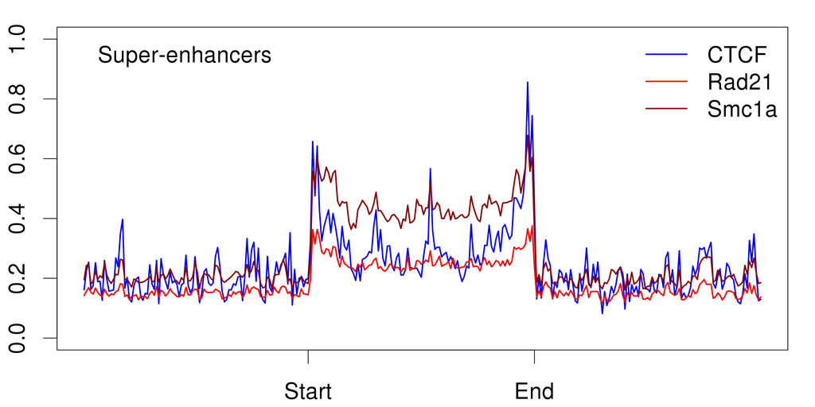

```r
## PLOT FIGURE 3B
par(cex=2, mar=c(2.1,2.1,1,1))
plot(colMeans(SE.plot.matrix.list$CTCF), type="l", ylab= "ChIP-seq signal",
     ylim =c(0,1), xaxt="n", xlab="", col="blue", lwd=2, ann=FALSE)
axis(side=1, at=c(size,size*2), labels=c("Start", "End"))

lines(colMeans(SE.plot.matrix.list$Rad21), col="red", lwd=2)
lines(colMeans(SE.plot.matrix.list$Smc1a), col="darkred", lwd=2)

legend("topright", legend = c("CTCF", "Rad21", "Smc1a"),
       col = c("blue", "red", "darkred"), lty=1, lwd=2, bty="n")
legend("topleft", legend="Super-enhancers", bty="n")
```

### Figure 3C – heatmaps of signal at super-enhancers grouped by CTCF binding

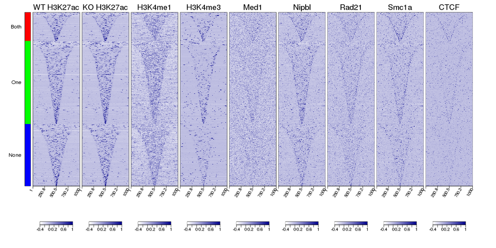

```r
load("/mnt/biggles/csc_projects/lizis/ES-DPT/DPT/DPT_GRanges_list.RData")
CTCF_peaks <- DPT_peaks$CTCF

starts <- resize(join_SEs, fix="start", width=1)
ends <- resize(join_SEs, fix="end", width=1)

start_CTCF_idx <- subjectHits(findOverlaps(CTCF_peaks, starts, maxgap=2000))
end_CTCF_idx <- subjectHits(findOverlaps(CTCF_peaks, ends, maxgap=2000))

both_CTCF <- join_SEs[join_SEs$ID %in% start_CTCF_idx & join_SEs$ID %in% end_CTCF_idx]
start_CTCF <- join_SEs[join_SEs$ID %in% start_CTCF_idx & !(join_SEs$ID %in% end_CTCF_idx)]
end_CTCF <- join_SEs[join_SEs$ID %in% end_CTCF_idx & !(join_SEs$ID %in% start_CTCF_idx)]
non_CTCF <- join_SEs[!(join_SEs$ID %in% end_CTCF_idx) & !(join_SEs$ID %in% start_CTCF_idx)]

both_CTCF_idx <- join_SEs[join_SEs$ID %in% start_CTCF_idx & join_SEs$ID %in% end_CTCF_idx]$ID
start2_CTCF_idx <- join_SEs[join_SEs$ID %in% start_CTCF_idx & !(join_SEs$ID %in% end_CTCF_idx)]$ID
end2_CTCF_idx <- join_SEs[join_SEs$ID %in% end_CTCF_idx & !(join_SEs$ID %in% start_CTCF_idx)]$ID
non_CTCF_idx <- join_SEs[!(join_SEs$ID %in% end_CTCF_idx) & !(join_SEs$ID %in% start_CTCF_idx)]$ID

windows <- resize(join_SEs, width=100000, fix="center")
targets <- c("WT H3K27ac" = "/mnt/biggles/csc_projects/lizis/HiC/VladThymocytes/mm9/ChIPSeq/H3K27ac/Aligned/DPT_WT1_H3K27ac_mm9.sam_sorted.bam",
  "KO H3K27ac" = "/mnt/biggles/csc_projects/lizis/HiC/VladThymocytes/mm9/ChIPSeq/H3K27ac/Aligned/DPT_KO1_H3K27ac_mm9.sam_sorted.bam",
  H3K4me1="/mnt/biggles/csc_projects/lizis/ES-DPT/DPT/Aligned/DPT_H3K4me1_sorted.bam",
  H3K4me3="/mnt/biggles/csc_projects/lizis/ES-DPT/DPT/Aligned/DPT_H3K4me3_sorted.bam",
    Med1 = "/mnt/biggles/csc_projects/lizis/ES-DPT/DPT/Aligned/DP_thymocyte_Med1_all_Vlad_sorted.bam",
    Nipbl="/mnt/biggles/csc_projects/lizis/ES-DPT/DPT/Aligned/DP_thymocyte_Nipbl_all_Vlad_m1_v2_sorted.bam",
    Rad21= "/mnt/biggles/csc_projects/lizis/ES-DPT/DPT/Aligned/DP_thymocyte_Rad21_all_m1_v2_Vlad_sorted.bam",
    Smc1a="/mnt/biggles/csc_projects/lizis/HiC/VladThymocytes/mm9/ChIPSeq//Smc1a//Smc1aRep1.sam_sorted.bam",
  CTCF="/mnt/biggles/csc_projects/lizis/ES-DPT/DPT/Aligned/DP_thymocyte_CTCF_Shih_sorted.bam")

joinSEs_smList<- ScoreMatrixList(windows=windows, targets=targets,
  bin.num=1000, type="bam")
names(joinSEs_smList) <- names(targets)

joinSEs_smList_outliers_removed <- lapply(joinSEs_smList, function(x){
  up_level <- quantile(x, 0.99)
  x[(x > up_level)] <- up_level
  down_level <- quantile(x,0.01)
  x[(x < down_level)] <- down_level
  return(x)
})
class(joinSEs_smList_outliers_removed) <- "ScoreMatrixList"

joinSEs_smList_scaled <- scaleScoreMatrixList(joinSEs_smList_outliers_removed)

multiHeatMatrix(joinSEs_smList_scaled, xcoords = NULL,
                group = list("Both"=both_CTCF_idx, "One"=c(start2_CTCF_idx,end2_CTCF_idx), "None"=non_CTCF_idx),
                common.scale=TRUE, xlab="", cex.main=1.5, col=c("white", "darkblue"))
```

## SIMA results

The HOMER Hi-C software analysis pipeline (http://biowhat.ucsd.edu/homer/interactions/) was used to determine significant interactions, differential interactions and to perform Structured Interaction Matrix Analysis (SIMA) (Lin et al., 2012).

To determine genomic features associated with chromatin interactions, we used SIMA, which pools Hi-C information associated with a given set of genomic regions within a specified set of domains (Lin et al., 2012). We used default resolution (“-res 2500”) and optimal Hi-C interaction search space parameters (“-superRes 10000”) to consider all reads within a 10kb window around the centre of each feature. Within-compartment associations were assessed independently in control and cohesin-deficient thymocytes for RAD21 peaks, canonical TSSs (excluding pseudogenes; Ensembl version 66), conventional enhancers (Shen et al. 2012) and random regions, as described previously (Seitan et al. 2013). Within-super-enhancer interactions were assessed for all super-enhancers of more than 100kb or 50kb in length. ‘Peaks’ within these regions were defined by taking the summits of constituent H3K27ac peaks, extending to 1kb and taking the intersection of these regions between all samples. Where super-enhancers that are not active in thymocytes were considered, as these contain no or very few H3K27ac peaks, we chose random “peaks” within them such that the number of peaks in each region was similar to the number of peaks in thymocyte super-enhancers of comparable size. All interactions were normalized using HOMER with a background model that takes sequencing depth and genomic distance between interacting regions into account.

### Figure 4D

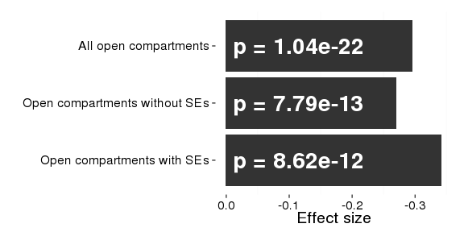

```r
sima_table <- read.table("~/HiC/data/sima_all_homotypic_Enhancer_ranked.csv",
                         header=TRUE, sep=",") #obtained from Andre Faure

sima_gr <- GRanges(seqnames=sima_table$chr.1.,
                   ranges=IRanges(sima_table$start.1., sima_table$end.1.),
                        mcols=data.frame(sima_table$X.DomainName.1., sima_table$PeakEnrichment,
                               sima_table$KO_PeakEnrichment, sima_table$KOWT_Ratio))

fO <- findOverlaps(join_SEs, sima_gr)
sima_without_SE <- sima_gr[-subjectHits(fO)]
sima_gr_with_SE <- subsetByOverlaps(sima_gr, join_SEs)

w <- wilcox.test(sima_gr_with_SE$mcols.sima_table.KOWT_Ratio, sima_without_SE$mcols.sima_table.KOWT_Ratio)
#can't use wilcoxsign_test from coin as diff numbers of rows

sima.bp <- data.frame(rbind(cbind(sima_gr_with_SE$mcols.sima_table.KOWT_Ratio, "With"),
    cbind(sima_without_SE$mcols.sima_table.KOWT_Ratio, "Without")))

names(sima.bp) <- c("KOWT_Ratio", "Group")

sima.bp$KOWT_Ratio <- as.numeric(as.character(sima.bp$KOWT_Ratio))

#barplot effect sizes
sima_all <- wilcoxsign_test(sima_gr$mcols.sima_table.KO_PeakEnrichment ~ sima_gr$mcols.sima_table.PeakEnrichment)
sima_without<- wilcoxsign_test(sima_without_SE$mcols.sima_table.KO_PeakEnrichment ~ sima_without_SE$mcols.sima_table.PeakEnrichment)
sima_with<- wilcoxsign_test(sima_gr_with_SE$mcols.sima_table.KO_PeakEnrichment ~ sima_gr_with_SE$mcols.sima_table.PeakEnrichment)

r_all <- as.numeric(statistic(sima_all, "test"))/sqrt(2*length(sima_gr))
r_without <- as.numeric(statistic(sima_without, "test"))/sqrt(2*length(sima_without_SE))
r_with <- as.numeric(statistic(sima_with, "test"))/sqrt(2*length(sima_gr_with_SE))

effect_size_df <- data.frame(Group=factor(c("with", "without", "all"),
                                          levels=c("with", "without", "all")),
                             Effect=c(r_with, r_without, r_all),
                             P=paste("p =",signif(c(as.numeric(pvalue(sima_with)),
                                                    as.numeric(pvalue(sima_without)),
                                                    as.numeric(pvalue(sima_all))),3)),
                             labs=c("Open compartments with SEs",
                                    "Open compartments without SEs",
                                    "All open compartments"))
labs <- effect_size_df$labs
ggplot(effect_size_df, aes(x=Group, y=Effect, label=P)) + geom_bar(stat="identity") +
    coord_flip() + scale_y_reverse("Effect size") +
    scale_x_discrete(name="",labels=labs) +
    geom_text(y=0, size=10, colour="white", fontface="bold", hjust=-0.05) +
  theme_bw(base_size=20) + theme(panel.border=element_blank(), panel.grid.major=element_blank())
```

```r
#note that initial '#' removed from these files to allow header to be read by R...
WT <- read.table("/mnt/biggles/csc_projects/lizis/HiC/VladThymocytes/mm9/HiC/SIMA/SIMA_output_WT.txt",
                 sep="\t", header=T)
KO <- read.table("/mnt/biggles/csc_projects/lizis/HiC/VladThymocytes/mm9/HiC/SIMA/SIMA_output_KO.txt",
                 sep="\t", header=T)

merged <- merge(WT, KO, by=names(WT)[1:12])
names(merged) <- sub("\\.x", "_WT", names(merged))
names(merged) <- sub("\\.y", "_KO", names(merged))

merged$region_size <- merged$end.1. - merged$start.1.
merged$KOWT_Ratio <- merged$Ratio_KO / merged$Ratio_WT

merged <- merged[order(merged$KOWT_Ratio),]
write.table(merged, file="SIMA_KOWT_results.txt", quote=F,
            sep="\t", row.names=F, col.names=T)

w <- wilcoxsign_test(merged$Ratio_KO ~ merged$Ratio_WT)
r <- as.numeric(statistic(w, "test"))/ sqrt(2*length(merged$Ratio_KO))

w1 <- wilcoxsign_test(merged$PeakEnrichment_KO ~ merged$PeakEnrichment_WT)
r1 <- as.numeric(statistic(w1, "test"))/ sqrt(2*length(merged$Ratio_KO))

w2 <- wilcoxsign_test(merged$RandEnrichment_KO ~ merged$RandEnrichment_WT)
r2 <- as.numeric(statistic(w2, "test"))/ sqrt(2*length(merged$Ratio_KO))
```

```r
#KOWT
df <- data.frame(Ratio=c(merged$Ratio_WT, merged$Ratio_KO),
                 PVal = c(merged$p.value_WT, merged$p.value_KO),
                 Group=c(rep("WT", length(merged$Ratio_WT)),
                         rep("KO", length(merged$Ratio_KO))))
```

To compare interactions within enhancer clusters to interactions within random regions, I ran SIMA within a set of shuffled regions of the same size as the super-enhancer regions and with the same number of constituent peaks randomly placed within them. Their positions were constrained to be in active chromatin compartments.

```r
#code used to shuffle regions and run SIMA
print(system("cat ~/HiC/SIMA_randomisation/run_random_SIMA.sh", intern=TRUE))
```

```
##  [1] "#! /bin/bash"
##  [2] ""
##  [3] "#bedtools intersect -a ~/HiC/ROSE_output_analysis/join_SEs_m100kb.bed -b ~/HiC/data/summits.intersect.bed -wb | awk '{print $5\"\\t\"$6\"\\t\"$7\"\\t\"$8\"\\t\"$9\"\\t\"$10}' > summits_in_SEs.bed #198 records"
##  [4] ""
##  [5] "#SBATCH -c 3"
##  [6] ""
##  [7] "i=$SLURM_ARRAY_TASK_ID"
##  [8] ""
##  [9] "echo \"shuffling\" $i"
## [10] "bedtools shuffle -i ~/HiC/ROSE_output_analysis/join_SEs_m100kb.bed -g ~/mm9_data/mm9.chrom.sizes -incl ~/HiC/data/compartmentsA.bed > temp${i}_SEs.bed"
## [11] "bedtools shuffle -i summits_in_SEs.bed -g ~/mm9_data/mm9.chrom.sizes -incl temp${i}_SEs.bed > temp${i}_summits_in_SEs.bed"
## [12] ""
## [13] "bed2pos.pl -unique temp${i}_SEs.bed > temp${i}_SEs.homer"
## [14] "bed2pos.pl temp${i}_summits_in_SEs.bed > temp${i}_summits_in_SEs.homer"
## [15] ""
## [16] "SIMA.pl /mnt/biggles/csc_projects/lizis/HiC/VladThymocytes/mm9/HiC/WT_HiC_HindIII/ -d temp${i}_SEs.homer -p temp${i}_summits_in_SEs.homer -cpu 3 -minDsize 100000 -max 50 > SIMA_output_WT${i}.txt"
## [17] "SIMA.pl /mnt/biggles/csc_projects/lizis/HiC/VladThymocytes/mm9/HiC/KO_HiC_HindIII/ -d temp${i}_SEs.homer -p temp${i}_summits_in_SEs.homer -cpu 3 -minDsize 100000 -max 50 > SIMA_output_KO${i}.txt"
## [18] ""
```

```r
columns <- c("DomainName1","chr1","start1","end1","DomainName2","chr2","start2",
             "end2","PeakFile1","PeakFile2","Npx","Npy","pvalue","Ratio",
             "PeakEnrichment","RandEnrichment")

results_df <- data.frame(matrix(0, nrow=21*500, ncol=20))
names(results_df) <- c(columns[1:12], paste0(columns[13:16], "_WT"),
                       paste0(columns[13:16], "_KO"))

for (i in 1:500){
  files <- list.files(path="~/HiC/SIMA_randomisation/",
                      pattern=paste0("SIMA_output_KO", i, ".txt", "|", "SIMA_output_WT", i, ".txt"),
                      full.names=TRUE)
  KO <- read.table(files[1], header=F, stringsAsFactors = FALSE, col.names=columns)
  WT <- read.table(files[2], header=F, stringsAsFactors = FALSE, col.names=columns)
  merged <- merge(WT,KO, by=columns[1:12])
  names(merged) <- sub("\\.x", "_WT", names(merged))
  names(merged) <- sub("\\.y", "_KO", names(merged))

  if (nrow(merged)!=21){
    warning(paste("wrong number of rows in sample", i))

    merged <- rbind(merged, rep(NA, 20))
  }

  results_df[((21*i)-20) : (21*i) ,] <- merged
}

results_df <- results_df[complete.cases(results_df),]


##Get significance results:

w <- wilcoxsign_test(merged$Ratio_KO ~ merged$Ratio_WT)
r <- as.numeric(statistic(w, "test"))/ sqrt(2*length(merged$Ratio_KO))

w1 <- wilcoxsign_test(merged$PeakEnrichment_KO ~ merged$PeakEnrichment_WT)
r1 <- as.numeric(statistic(w1, "test"))/ sqrt(2*length(merged$Ratio_KO))

w2 <- wilcoxsign_test(merged$RandEnrichment_KO ~ merged$RandEnrichment_WT)
r2 <- as.numeric(statistic(w2, "test"))/ sqrt(2*length(merged$Ratio_KO))
```

```r
#KOWT
df <- data.frame(Ratio=c(merged$Ratio_WT, merged$Ratio_KO),
                 PVal = c(merged$pvalue_WT, merged$pvalue_KO),
                 Group=c(rep("WT", length(merged$Ratio_WT)),
                         rep("KO", length(merged$Ratio_KO))))
```

To compare to interactions between enhancers and interactions in random regions, I have also carried out SIMA using other features: transcription start sites, Rad21 peaks, CTCF peaks and 'random' peaks (all obtained from Andre). The following graphs represent this analysis within enhancer clusters / random regions of similar size.

```r
files <- list.files(path="~/HiC/SIMA_extra/", pattern="SIMA_output.txt", full.names=TRUE)
files <- files[-grep("comp", files)]
names <- unique(sapply(files, function(f){
               x <- strsplit(f, "/")[[1]]
               strsplit(x[length(x)], ".", fixed=TRUE)[[1]][1]
  }))

tables <- lapply(names, function(n){
  fs <- files[grep(n, files)]

  #read real regions
  KO <- read.table(fs[2], header=F, stringsAsFactors = FALSE, col.names=columns)
  WT <- read.table(fs[4], header=F, stringsAsFactors = FALSE, col.names=columns)
  merged <- merge(WT,KO, by=columns[1:12])
  names(merged) <- sub("\\.x", "_WT", names(merged))
  names(merged) <- sub("\\.y", "_KO", names(merged))
  real_regions <- merged

  #read random regions
  KO <- read.table(fs[1], header=F, stringsAsFactors = FALSE, col.names=columns)
  WT <- read.table(fs[3], header=F, stringsAsFactors = FALSE, col.names=columns)
  merged <- merge(WT,KO, by=columns[1:12])
  names(merged) <- sub("\\.x", "_WT", names(merged))
  names(merged) <- sub("\\.y", "_KO", names(merged))

  random_regions <- merged

  return(list(real_regions, random_regions, n))

})

names(tables) <- names
```

```r
files <- list.files(path="~/HiC/SIMA_extra/", pattern="SIMA_output.txt", full.names=TRUE)
files <- files[grep("comp", files)]
names <- unique(sapply(files, function(f){
               x <- strsplit(f, "/")[[1]]
               strsplit(x[length(x)], ".", fixed=TRUE)[[1]][1]
  }))

tables <- lapply(names, function(n){
  fs <- files[grep(n, files)]

  #read real regions
  KO <- read.table(fs[1], header=F, stringsAsFactors = FALSE, col.names=columns)
  WT <- read.table(fs[2], header=F, stringsAsFactors = FALSE, col.names=columns)
  merged <- merge(WT,KO, by=columns[1:12])
  names(merged) <- sub("\\.x", "_WT", names(merged))
  names(merged) <- sub("\\.y", "_KO", names(merged))
  real_regions <- merged

  return(list(real_regions, n))

})

names(tables) <- names

counts <- nrow(tables[[1]][[1]])
```

### Figure 4C

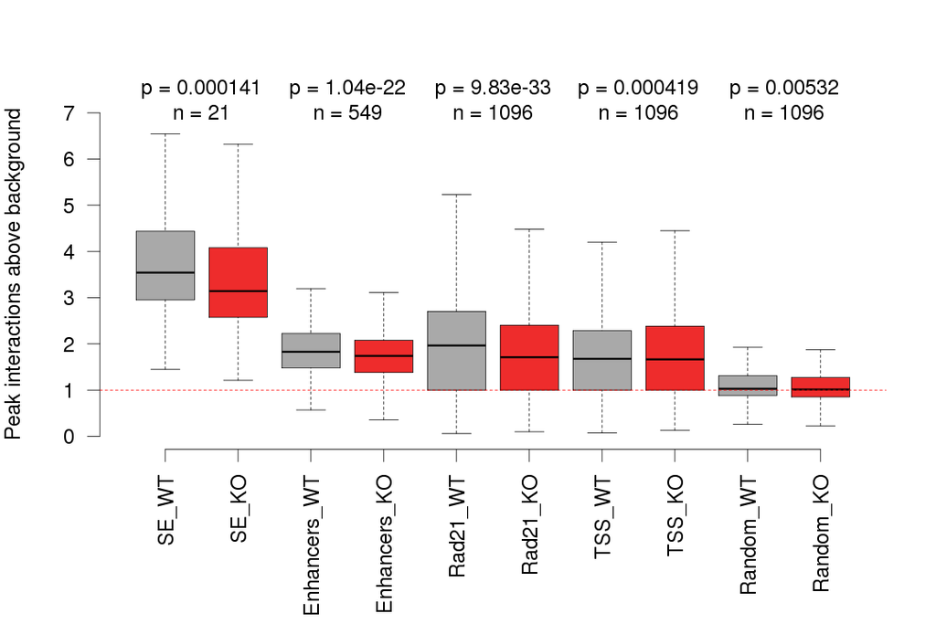

```r
#Collate data to show that the magnitude of enh-enh interaction reduction in enhancer clusters is compaarable
#to reduction in interaction between cohesin binding sites
EE_in_SE <- read.table("SIMA_KOWT_results.txt", sep="\t", header=TRUE)

EE_in_comp <- read.table("~/HiC/data/sima_all_homotypic_Enhancer_ranked.csv", header=TRUE, sep=",")

df <- data.frame(Interaction = c(tables$Rad21_peaks[[1]]$PeakEnrichment_WT,
                                 tables$Rad21_peaks[[1]]$PeakEnrichment_KO,
                                 tables$TSS[[1]]$PeakEnrichment_WT,
                                 tables$TSS[[1]]$PeakEnrichment_KO,
                                tables$Random_peaks[[1]]$PeakEnrichment_WT,
                                tables$Random_peaks[[1]]$PeakEnrichment_KO,
                                EE_in_comp$PeakEnrichment,
                                EE_in_comp$KO_PeakEnrichment,
                                EE_in_SE$PeakEnrichment_WT,
                                EE_in_SE$PeakEnrichment_KO),
                Group=c(rep("Rad21_WT", counts), rep("Rad21_KO", counts),
                        rep("TSS_WT", counts), rep("TSS_KO", counts),
                        rep("Random_WT", counts), rep("Random_KO", counts),
                        rep("Enhancers_WT", nrow(EE_in_comp)),
                        rep("Enhancers_KO", nrow(EE_in_comp)),
                        rep("SE_WT", 21), rep("SE_KO", 21)))

df$Group <- factor(df$Group, levels=c("SE_WT", "SE_KO", "Enhancers_WT", "Enhancers_KO",
                                      "Rad21_WT", "Rad21_KO", "TSS_WT", "TSS_KO",
                                      "Random_WT", "Random_KO"))

p_EE_SE <- pvalue(wilcoxsign_test(df$Interaction[df$Group=="SE_KO"] ~ df$Interaction[df$Group=="SE_WT"]))
r_EE_SE <- statistic(wilcoxsign_test(df$Interaction[df$Group=="SE_KO"] ~ df$Interaction[df$Group=="SE_WT"])) /
  sqrt(2*sum(df$Group=="SE_KO"))

p_EE <- pvalue(wilcoxsign_test(df$Interaction[df$Group=="Enhancers_KO"] ~ df$Interaction[df$Group=="Enhancers_WT"]))
r_EE <- statistic(wilcoxsign_test(df$Interaction[df$Group=="Enhancers_KO"] ~ df$Interaction[df$Group=="Enhancers_WT"])) /
  sqrt(2*sum(df$Group=="Enhancers_KO"))

p_Rad21 <- pvalue(wilcoxsign_test(df$Interaction[df$Group=="Rad21_KO"] ~ df$Interaction[df$Group=="Rad21_WT"]))
r_Rad21 <- statistic(wilcoxsign_test(df$Interaction[df$Group=="Rad21_KO"] ~ df$Interaction[df$Group=="Rad21_WT"])) /
  sqrt(2*sum(df$Group=="Rad21_KO"))

p_TSS <- pvalue(wilcoxsign_test(df$Interaction[df$Group=="TSS_KO"] ~ df$Interaction[df$Group=="TSS_WT"]))
r_TSS <- statistic(wilcoxsign_test(df$Interaction[df$Group=="TSS_KO"] ~ df$Interaction[df$Group=="TSS_WT"])) /
  sqrt(2*sum(df$Group=="TSS_KO"))

p_rand <- pvalue(wilcoxsign_test(df$Interaction[df$Group=="Random_KO"] ~ df$Interaction[df$Group=="Random_WT"]))
r_rand <- statistic(wilcoxsign_test(df$Interaction[df$Group=="Random_KO"] ~ df$Interaction[df$Group=="Random_WT"])) /
  sqrt(2*sum(df$Group=="Random_KO"))

par(cex=2, bty="n", mar=c(7,4,4,2))
boxplot(Interaction~Group, data=df, ylab="Peak interactions above background",
          outline=F, col=c("darkgrey", "firebrick2"), ylim=c(0,7), las=2)
abline(h=1, lty=2, col="red")

labs <- c(paste0("p = ", signif(p_EE_SE,3),"\n", "n = ", sum(df$Group=="SE_KO")),
          paste0("p = ", signif(p_EE,3),"\n", "n = ", sum(df$Group=="Enhancers_KO")),
          paste0("p = ", signif(p_Rad21,3),"\n", "n = ", sum(df$Group=="Rad21_KO")),
          paste0("p = ", signif(p_TSS,3),"\n", "n = ", sum(df$Group=="TSS_KO")),
          paste0("p = ", signif(p_rand,3),"\n", "n = ", sum(df$Group=="Random_KO")))
axis(side=3, at=c(1.5, 3.5, 5.5, 7.5, 9.5), labels=labs, tick=F, line=-2, cex=1)
```

### Figure 5A – comparison to CTCF and cohesin signal in super-enhancers from other cell types

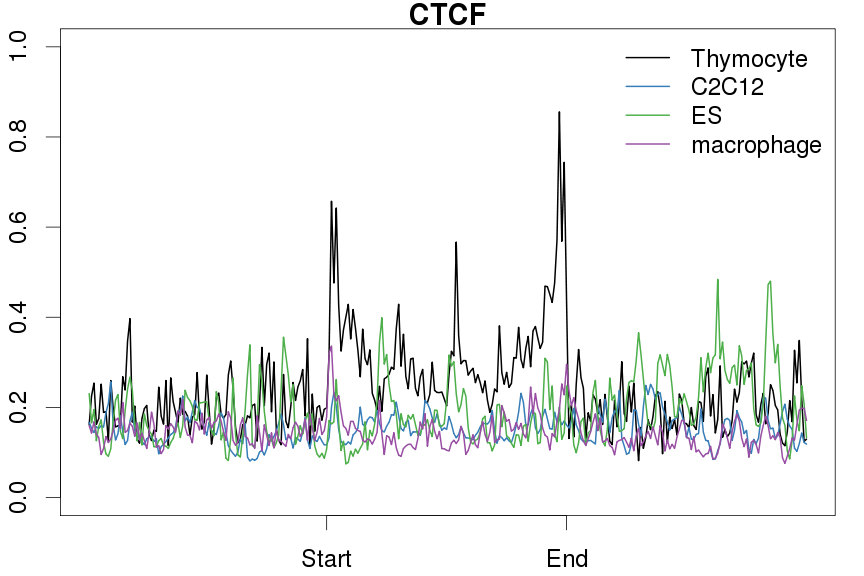

```r
bed_files <- as.list(list.files("~/HiC/data/", pattern="Whyte_super_enhancers_", full.names=TRUE))
bed_files <- bed_files[-grep("test|tracklines", bed_files)]

other_SE_list <- lapply(bed_files, function(x){
    tmp <- read.table(x, header = FALSE, stringsAsFactors = FALSE, col.names = c("chr", "start", "end"), skip=1)
    makeGRangesFromDataFrame(tmp)
})

bed_names <- sapply(bed_files, function(x){
  ns <- strsplit(x, "/|\\.|_")
  return(ns[[1]][length(ns[[1]])-1])})
names(other_SE_list) <- bed_names
other_SE_list$all <- unlist(GRangesList(other_SE_list[1:5]))

normalised_coverage_list_short <- list(Rad21=normalised_coverage_list$Rad21,
                                       CTCF=normalised_coverage_list$CTCF_Shih,
                                       Smc1a=normalised_coverage_list$Smc1a)

size <- 100
other_SE_coverage_list <- lapply(other_SE_list, function(SE){
  tmp <- lapply(normalised_coverage_list_short, function(cov){generate.plot.matrix(cov, SE, size)})
  names(tmp) <- names(normalised_coverage_list_short)
  return(tmp)
})

colours <- brewer.pal(5, "Set1")

par(cex=2, mar=c(2.1,2.1,1,1))
plot(colMeans(SE.plot.matrix.list$CTCF), type="l", lty=1,
     ylab= "Coverage (rpm)", xaxt="n", xlab="", col="black",
     lwd=2, main="CTCF", ylim=c(0,1))
axis(side=1, at=c(size,size*2), labels=c("Start", "End"))

lines(colMeans(other_SE_coverage_list$C2C12$CTCF), lwd=2, col=colours[2])
lines(colMeans(other_SE_coverage_list$ES$CTCF), lwd=2, col=colours[3])
lines(colMeans(other_SE_coverage_list$macrophage$CTCF), lwd=2, col=colours[4])

legend("topright", legend = c("Thymocyte", "Th", "C2C12", "ES", "macrophage", "proB")[c(1,3:5)],
       col=c("black", colours)[c(1,3:5)], lwd=2, bty="n")
```

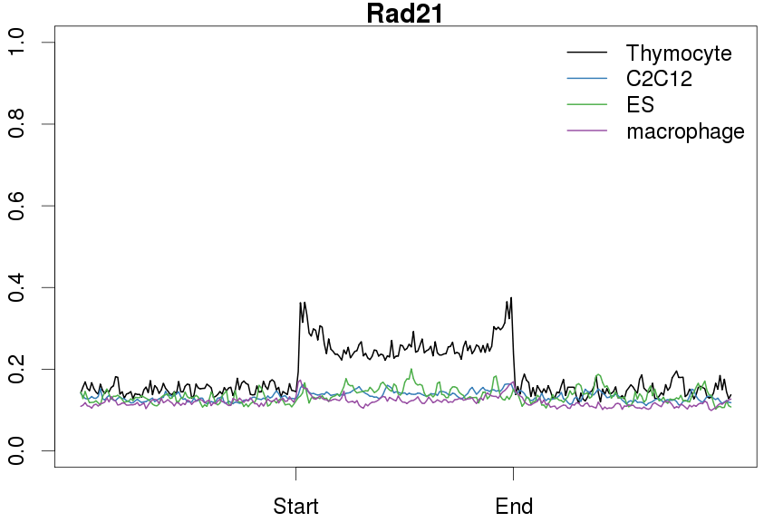

```r
par(cex=2, mar=c(2.1,2.1,1,1))
plot(colMeans(SE.plot.matrix.list$Rad21), type="l", lty=1,
     ylab= "Coverage (rpm)", xaxt="n", xlab="", col="black",
     lwd=2, main="Rad21",ylim=c(0,1))
axis(side=1, at=c(size,size*2), labels=c("Start", "End"))

lines(colMeans(other_SE_coverage_list$C2C12$Rad21), lwd=2, col=colours[2])
lines(colMeans(other_SE_coverage_list$ES$Rad21), lwd=2, col=colours[3])
lines(colMeans(other_SE_coverage_list$macrophage$Rad21), lwd=2, col=colours[4])

legend("topright", legend = c("Thymocyte", "Th", "C2C12", "ES", "macrophage", "proB")[c(1,3:5)],
       col=c("black", colours)[c(1,3:5)], lwd=2, bty="n")
```

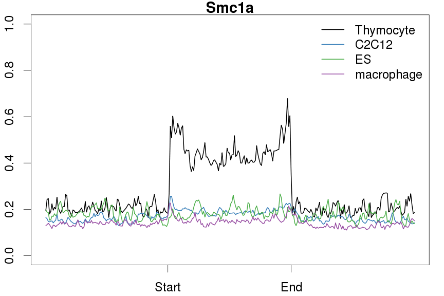

```r
par(cex=2, mar=c(2.1,2.1,1,1))
plot(colMeans(SE.plot.matrix.list$Smc1a), type="l", lty=1,
     ylab= "Coverage (rpm)", xaxt="n", xlab="", col="black",
     lwd=2, main="Smc1a",ylim=c(0,1))
axis(side=1, at=c(size,size*2), labels=c("Start", "End"))

lines(colMeans(other_SE_coverage_list$C2C12$Smc1a), lwd=2, col=colours[2])
lines(colMeans(other_SE_coverage_list$ES$Smc1a), lwd=2, col=colours[3])
lines(colMeans(other_SE_coverage_list$macrophage$Smc1a), lwd=2, col=colours[4])

legend("topright", legend = c("Thymocyte", "Th", "C2C12", "ES", "macrophage", "proB")[c(1,3:5)],
       col=c("black", colours)[c(1,3:5)], lwd=2, bty="n")
```

### Figure 5B

The next set of graphs show the SIMA analysis repeated for all super-enhancers more than 50kb in length in order to compare them to super-enhancers from other cell types, all of which are less than 100kb, but 20 of which are more than 50kb. These super-enhancers for other cell types are taken from Whyte et al.

```r
WT <- read.table("/mnt/biggles/csc_projects/lizis/HiC/VladThymocytes/mm9/HiC/SIMA/SIMA_output_WT_50kb.txt",
                 sep="\t", header=F, stringsAsFactors = FALSE, col.names=columns)
KO <- read.table("/mnt/biggles/csc_projects/lizis/HiC/VladThymocytes/mm9/HiC/SIMA/SIMA_output_KO_50kb.txt",
                 sep="\t", header=F, stringsAsFactors = FALSE, col.names=columns)

merged <- merge(WT, KO, by=names(WT)[1:12])
names(merged) <- sub("\\.x", "_WT", names(merged))
names(merged) <- sub("\\.y", "_KO", names(merged))

WT_other <- read.table("/mnt/biggles/csc_projects/lizis/HiC/VladThymocytes/mm9/HiC/SIMA/50kb/SIMA_output_longEnh_WT_50kb.txt",
                       sep="\t", header=F, stringsAsFactors = FALSE, col.names=columns)
KO_other <- read.table("/mnt/biggles/csc_projects/lizis/HiC/VladThymocytes/mm9/HiC/SIMA/50kb/SIMA_output_longEnh_KO_50kb.txt",
                       sep="\t", header=F, stringsAsFactors = FALSE, col.names=columns)

merged_other <- merge(WT_other, KO_other, by=names(WT)[1:12])
names(merged_other) <- sub("\\.x", "_WT", names(merged_other))
names(merged_other) <- sub("\\.y", "_KO", names(merged_other))
```

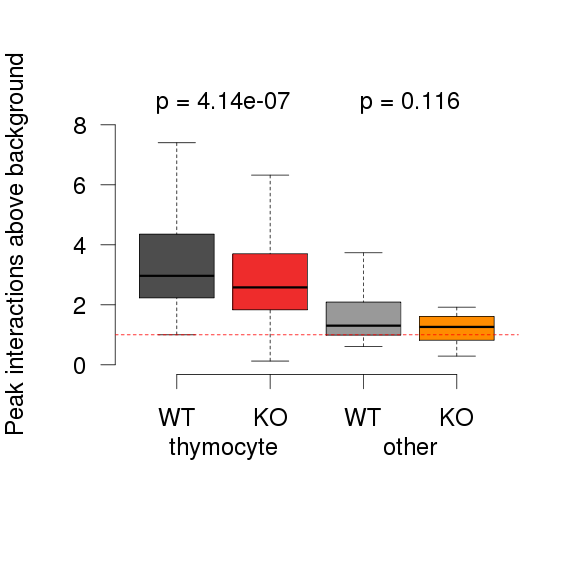

```r
df <- data.frame(Peaks=c(merged$PeakEnrichment_WT, merged$PeakEnrichment_KO,
                         merged_other$PeakEnrichment_WT, merged_other$PeakEnrichment_KO),
                 Random = c(merged$RandEnrichment_WT, merged$RandEnrichment_KO,
                            merged_other$RandEnrichment_WT, merged_other$RandEnrichment_KO),
                 Ratio = c(merged$Ratio_WT, merged$Ratio_KO,
                           merged_other$Ratio_WT, merged_other$Ratio_KO),

                 Group=c(rep("WT DP", length(merged$Ratio_WT)),
                         rep("KO DP", length(merged$Ratio_KO)),
                         rep("WT other", length(merged_other$Ratio_WT)),
                         rep("KO other", length(merged_other$Ratio_KO))))

df$Group <- factor(df$Group, levels=c("WT DP", "KO DP", "WT other", "KO other"))

p_SE_DP <- pvalue(wilcoxsign_test(df$Peaks[df$Group=="KO DP"] ~ df$Peaks[df$Group=="WT DP"]))
r_SE_DP <- statistic(wilcoxsign_test(df$Peaks[df$Group=="KO DP"] ~ df$Peaks[df$Group=="WT DP"])) /
  sqrt(2*sum(df$Group=="KO DP"))

p_SE_other <- pvalue(wilcoxsign_test(df$Peaks[df$Group=="KO other"] ~ df$Peaks[df$Group=="WT other"]))
r_SE_other <- statistic(wilcoxsign_test(df$Peaks[df$Group=="KO other"] ~ df$Peaks[df$Group=="WT other"])) /
  sqrt(2*sum(df$Group=="KO other"))


par(cex=2, bty="n", mar=c(7,4,4,2))
boxplot(Peaks~Group, data=df, ylab="Peak interactions above background",
          outline=F, col=c("grey30", "firebrick2", "grey60", "darkorange"),
        ylim=c(0,8), las=2, xaxt="n")
abline(h=1, lty=2, col="red")

labs <- c(paste0("p = ", signif(p_SE_DP,3),"\n"),
          paste0("p = ", signif(p_SE_other,3),"\n"))
axis(side=3, at=c(1.5, 3.5), labels=labs, tick=F, line=-2, cex=1)
axis(side=1, at=1:4, labels=c("WT", "KO", "WT", "KO"), cex=1)
axis(side=1, at=c(1.5, 3.5), labels=c("thymocyte", "other"), line =1, cex=1, tick=FALSE)
```

## Supplementary Figures

### Figure S1B

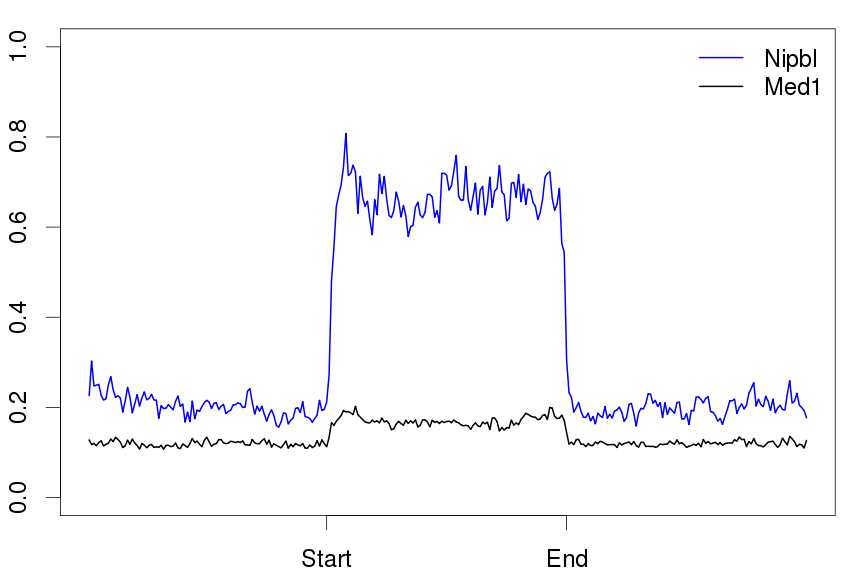

```r
par(cex=2, mar=c(2.1,2.1,1,1))
plot(colMeans(SE.plot.matrix.list$Nipbl), type="l", ylab= "Coverage (rpm)",
     ylim =c(0,1), xaxt="n", xlab="", col="blue", lwd=2)
axis(side=1, at=c(size,size*2), labels=c("Start", "End"))

lines(colMeans(SE.plot.matrix.list$Med1), col="black", lwd=2)
legend("topright", legend = c("Nipbl", "Med1"), col = c("blue", "black"),
       lty=1, lwd=2, bty="n")
```

### Figure S1A

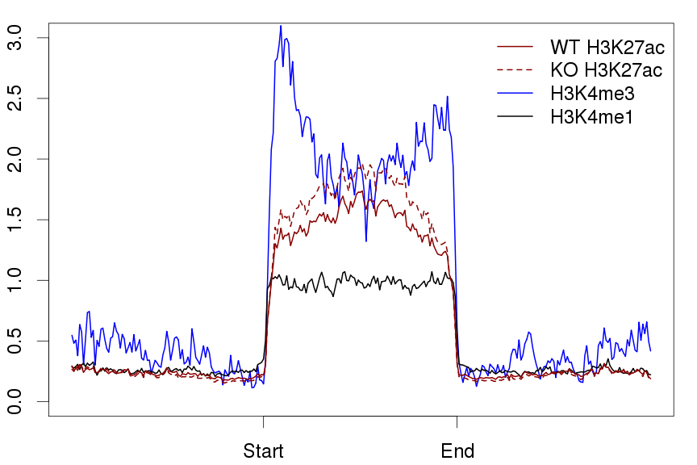

```r
par(cex=2, mar=c(2.1,2.1,1,1))
WT <- (colMeans(SE.plot.matrix.list$WT1) + colMeans(SE.plot.matrix.list$WT2))/2
KO <- (colMeans(SE.plot.matrix.list$KO1) + colMeans(SE.plot.matrix.list$KO2))/2

plot(colMeans(SE.plot.matrix.list$H3K4me3), type="l", ylab= "Coverage (rpm)",
     ylim =c(0,3), xaxt="n", xlab="", col="blue", lwd=2)
axis(side=1, at=c(size,size*2), labels=c("Start", "End"))
lines(colMeans(SE.plot.matrix.list$H3K4me1), col="black", lwd=2)

lines(WT, col="darkred", lwd=2)
lines(KO, col="darkred", lwd=2, lty=2)

legend("topright", legend = c("WT H3K27ac", "KO H3K27ac", "H3K4me3", "H3K4me1"),
       col = c("darkred", "darkred", "blue", "black"), lty=c(1,2,1,1), lwd=2, bty="n")
```

### Other distance cut-offs for gene association with SEs

```r
promoters <- ensGene_tss.gr[ensGene_tss.gr$ensG %in% gene_expr.df$ensG]

cutoffs <- list(0, 10000, 20000, 30000, 40000, 50000, 75000, 100000)

DE_by_distance <- lapply(cutoffs, function(cutoff){
  fO <- findOverlaps(promoters, join_SEs, maxgap=cutoff)
  nearby_promoters <- promoters[queryHits(fO)]
  nearby_genes <- gene_expr.df[match(nearby_promoters$ensG, gene_expr.df$ensG),]
  rownames(nearby_genes) <- NULL
  nearby_genes <- unique(nearby_genes)

  up <- sum(nearby_genes$DE_up)
  down <- sum(nearby_genes$DE_down)
  total <- nrow(nearby_genes)

  return(c(up, down, total-up-down, cutoff))
})

#genome avg
up <- sum(gene_expr.df$DE_up)
down <- sum(gene_expr.df$DE_down)
total <- nrow(gene_expr.df)

#make data frame
DE_df <- as.data.frame(do.call(rbind, DE_by_distance))

DE_df <- rbind(DE_df, list(up, down, total-up-down, "Genome average"))

colnames(DE_df) <- c("Up", "Down", "No", "Cutoff")
kable(DE_df)
```

| Up | Down | No | Cutoff |
| --- | --- | --- | --- |
| 67 | 71 | 355 | 0 |
| 76 | 80 | 465 | 10000 |
| 84 | 89 | 583 | 20000 |
| 91 | 103 | 703 | 30000 |
| 97 | 110 | 829 | 40000 |
| 103 | 115 | 953 | 50000 |
| 116 | 125 | 1284 | 75000 |
| 127 | 139 | 1591 | 1e+05 |
| 703 | 450 | 15850 | Genome average |

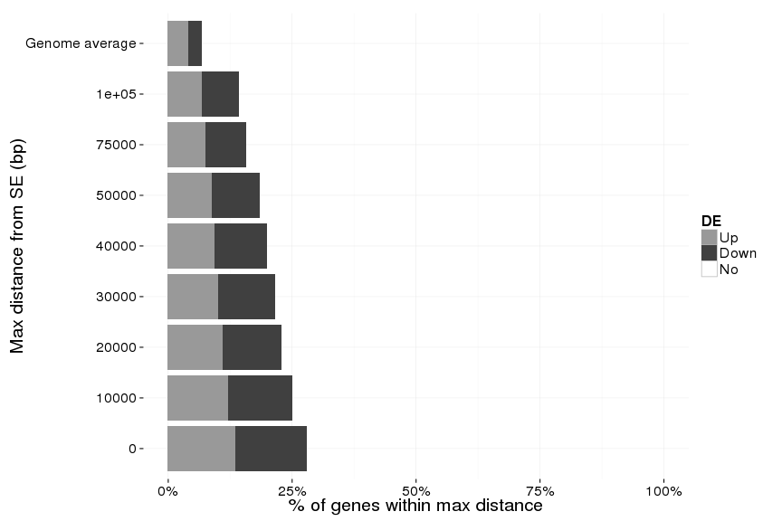

```r
DE_df <- gather(DE_df, DE, Value, -Cutoff)
DE_df$Cutoff <- factor(DE_df$Cutoff, levels=c(cutoffs, "Genome average"), ordered=TRUE)

cols <- c("No" = NA, "Up" = col_up, "Down" = col_down)

ggplot(DE_df, aes(x=Cutoff, fill=DE, y=Value)) + geom_bar(stat="identity", position="fill") +
  scale_x_discrete("Max distance from SE (bp)") +
  scale_y_continuous("% of genes within max distance",labels=percent) +
  scale_fill_manual(values=cols) +
  theme_bw(base_size=20) + theme(panel.border=element_blank()) + coord_flip()
```

```r
groups <- unique(DE_df$Cutoff[DE_df$Cutoff!="Genome average"])
for (g in groups){
  print(paste0("Comparing all expressed genes and ", g, ":"))

  DE_df %>%
    filter(Cutoff %in% c("Genome average", g)) %>%
      spread(DE, Value)%>%
      dplyr::select(No,Up,Down) %>%
    (function(x){x[2,] <- x[2,]-x[1,]
                 return(x)}) %>%  print()

 DE_df %>%
    filter(Cutoff %in% c("Genome average", g)) %>%
      spread(DE, Value)%>%
      dplyr::select(No,Up,Down) %>%
    (function(x){x[2,] <- x[2,]-x[1,]
                 return(x)}) %>%
    as.matrix() %>%
    chisq.test() %>% print()
  }
```

```
## [1] "Comparing all expressed genes and 0:"
##      No  Up Down
## 1   355  67   71
## 2 15495 636  379
##
##  Pearson's Chi-squared test
##
## data:  DE_df %>% filter(Cutoff %in% c("Genome average", g)) %>% spread(DE,     Value) %>% dplyr::select(No, Up, Down) %>% (function(x) {    x[2, ] <- x[2, ] - x[1, ]    return(x)}) %>% as.matrix()
## X-squared = 399.3844, df = 2, p-value < 2.2e-16
##
## [1] "Comparing all expressed genes and 10000:"
##      No  Up Down
## 1   465  76   80
## 2 15385 627  370
##
##  Pearson's Chi-squared test
##
## data:  DE_df %>% filter(Cutoff %in% c("Genome average", g)) %>% spread(DE,     Value) %>% dplyr::select(No, Up, Down) %>% (function(x) {    x[2, ] <- x[2, ] - x[1, ]    return(x)}) %>% as.matrix()
## X-squared = 380.7899, df = 2, p-value < 2.2e-16
##
## [1] "Comparing all expressed genes and 20000:"
##      No  Up Down
## 1   583  84   89
## 2 15267 619  361
##
##  Pearson's Chi-squared test
##
## data:  DE_df %>% filter(Cutoff %in% c("Genome average", g)) %>% spread(DE,     Value) %>% dplyr::select(No, Up, Down) %>% (function(x) {    x[2, ] <- x[2, ] - x[1, ]    return(x)}) %>% as.matrix()
## X-squared = 364.1092, df = 2, p-value < 2.2e-16
##
## [1] "Comparing all expressed genes and 30000:"
##      No  Up Down
## 1   703  91  103
## 2 15147 612  347
##
##  Pearson's Chi-squared test
##
## data:  DE_df %>% filter(Cutoff %in% c("Genome average", g)) %>% spread(DE,     Value) %>% dplyr::select(No, Up, Down) %>% (function(x) {    x[2, ] <- x[2, ] - x[1, ]    return(x)}) %>% as.matrix()
## X-squared = 384.4905, df = 2, p-value < 2.2e-16
##
```

[output cut: 24 more lines]

```
##
##  Pearson's Chi-squared test
##
## data:  DE_df %>% filter(Cutoff %in% c("Genome average", g)) %>% spread(DE,     Value) %>% dplyr::select(No, Up, Down) %>% (function(x) {    x[2, ] <- x[2, ] - x[1, ]    return(x)}) %>% as.matrix()
## X-squared = 258.4564, df = 2, p-value < 2.2e-16
##
## [1] "Comparing all expressed genes and 1e+05:"
##      No  Up Down
## 1  1591 127  139
## 2 14259 576  311
##
##  Pearson's Chi-squared test
##
## data:  DE_df %>% filter(Cutoff %in% c("Genome average", g)) %>% spread(DE,     Value) %>% dplyr::select(No, Up, Down) %>% (function(x) {    x[2, ] <- x[2, ] - x[1, ]    return(x)}) %>% as.matrix()
## X-squared = 234.0145, df = 2, p-value < 2.2e-16
```

## Session details

This report was generated on Wed Dec 17 2014 at 16:07:40.